# Spatial and Economic Prioritization for Distributed Wind

# Study Overview and Reproducibility

This notebook accompanies the analysis from the article:

**“Spatial and Economic Prioritization for Distributed Wind”**

It explores how distributed wind (DW) energy can be strategically deployed in areas with elevated energy burdens by analyzing spatial, economic, and demographic factors. The analysis includes custom energy burden metrics, demand-adjusted annual energy production $AEP_{\text{Demand}}$, and statistical modeling (mixed-effects and fixed-effects regressions).

The code and data used here ensure full reproducibility of the results presented in the study, including all figures and model outputs. This notebook is designed to allow other researchers to validate, extend, or reuse the methodology.

This notebook follows the same numeration than the article in order to facilitate finding the data and its reproducibility.

# 1. Introduction

This research builds on these prior efforts while leveraging [National Renewable Energy Laboratory’s (NREL) Distributed Wind Energy Futures Study (DWEFS) (Lockshin et al., 2025)](https://wes.copernicus.org/articles/10/1231/2025/), which provides parcel-level techno-economic assessments for distributed wind under recent (2025) and projected future (2035) scenarios. The DWEFS model incorporates land use, siting constraints, electricity demand, wind resource availability, and policy context to size systems and simulate energy generation potential.

The summarized data by county is like this:

```python
import sys
import re
import io
import tomllib
import requests
import sqlalchemy as sa
import pandas as pd
import numpy as np
import geopandas as gp
import seaborn as sns
from matplotlib.ticker import FuncFormatter
import matplotlib.pyplot as plt
import seaborn as sns
import numpy as np

pd.set_option("display.max_columns", None)

import os
os.chdir(os.path.expanduser('~/Downloads/dwfs_postgis-main'))
conf = tomllib.load(open("./config.toml", "rb"))
secret = tomllib.load(open("./secret.toml", "rb"))
```

```python
def get_db_engine():
    url = sa.engine.URL.create(
        drivername="postgresql+psycopg2",
        database=secret["atlas"]["database"],
        host=secret["atlas"]["hostname"],
        username=secret["atlas"]["username"],
        password=secret["atlas"].get("password"),  # optional, if not specified will search for .pgpass
    )
    return sa.create_engine(url)
```

```python
# URL to have the FIPS
url = "https://raw.githubusercontent.com/kjhealy/fips-codes/master/state_and_county_fips_master.csv"
decoder_ring = pd.read_csv(url, dtype={"fips": str})
decoder_ring["fips"] = decoder_ring["fips"].str.zfill(5)
der_ring = decoder_ring[~decoder_ring["fips"].str.endswith("000")]


decoder_ring = decoder_ring.rename(columns={
    "fips": "fips",
    "state_abbrev": "state",
    "name": "county"
})[["fips", "state", "county"]]


decoder_ring = decoder_ring[~decoder_ring["state"].isin(["AK", "HI"])]


ct_fips_codes = ["09001", "09003", "09005", "09007", "09009", "09011", "09013", "09015"]
ct_names = [
    "Fairfield County", "Hartford County", "Litchfield County", "Middlesex County",
    "New Haven County", "New London County", "Tolland County", "Windham County"
]

for fips, name in zip(ct_fips_codes, ct_names):
    decoder_ring.loc[decoder_ring["fips"] == fips, "county"] = name
```

```python
def setAEPdf(df: pd.DataFrame) -> pd.DataFrame:
    df = df.rename(columns={"countyfp": "fips"})

    # Merge with decoder_ring on fips
    df = decoder_ring.merge(df, on="fips", how="left")
    # Convert from kWh to TWh
    for col in [
        "cost_viable_aep_sum",
        "cost_viable_res_aep_sum",
        "cost_viable_com_aep_sum",
        "cost_viable_ind_aep_sum"
    ]:
        df[col] = df[col] * 1e-9
    # Rename columns
    df = df.rename(columns={
        "cost_viable_aep_sum": "cost_viable_aep_sum_twh",
        "cost_viable_res_aep_sum": "cost_viable_res_aep_sum_twh",
        "cost_viable_com_aep_sum": "cost_viable_com_aep_sum_twh",
        "cost_viable_ind_aep_sum": "cost_viable_ind_aep_sum_twh",
    })

    # Filter out rows where all *_twh columns are NA
    twh_cols = [
        "cost_viable_aep_sum_twh",
        "cost_viable_res_aep_sum_twh",
        "cost_viable_com_aep_sum_twh",
        "cost_viable_ind_aep_sum_twh"
    ]
    df = df[~df[twh_cols].isna().all(axis=1)]

    return df
```

```python
def getAllData(model_run: str) -> pd.DataFrame:
    query = f"""
    WITH county_agg AS (
      SELECT
        r.run_id,
        a.countyfp,
        SUM(r.wind_aep_kwh) FILTER (WHERE r.breakeven_cost >= bt.breakeven_threshold) AS cost_viable_aep_sum,
        SUM(r.wind_aep_kwh) FILTER (WHERE r.breakeven_cost >= bt.breakeven_threshold AND a.sector_abbr = 'res') AS cost_viable_res_aep_sum,
        SUM(r.wind_aep_kwh) FILTER (WHERE r.breakeven_cost >= bt.breakeven_threshold AND a.sector_abbr = 'com') AS cost_viable_com_aep_sum,
        SUM(r.wind_aep_kwh) FILTER (WHERE r.breakeven_cost >= bt.breakeven_threshold AND a.sector_abbr = 'ind') AS cost_viable_ind_aep_sum,
        SUM(r.techpot_kw) FILTER (WHERE r.breakeven_cost >= bt.breakeven_threshold) AS cost_viable_techpot_sum,
        SUM(r.capacity_kw) FILTER (WHERE r.breakeven_cost >= bt.breakeven_threshold) AS cost_viable_capacity_sum,
        SUM(r.wind_aep_kwh) FILTER (WHERE r.breakeven_cost >= 0) AS positive_breakeven_aep_sum,
        SUM(r.techpot_kw) FILTER (WHERE r.breakeven_cost >= 0) AS positive_breakeven_techpot_sum,
        SUM(r.capacity_kw) FILTER (WHERE r.breakeven_cost >= 0) AS positive_breakeven_capacity_sum
      FROM dwind.result r
      JOIN dwind.model_run mr USING (run_id)
      JOIN dwind.agent a USING (gid)
      JOIN dwind.breakeven_threshold bt USING (run_id, capacity_kw)
      WHERE r.run_id = '{model_run}'
      GROUP BY r.run_id, a.countyfp
    )

    SELECT
      a.countyfp,
      a.cost_viable_res_aep_sum,
      a.cost_viable_com_aep_sum,
      a.cost_viable_ind_aep_sum,
      a.cost_viable_aep_sum,
      a.cost_viable_techpot_sum,
      a.cost_viable_capacity_sum,
      a.positive_breakeven_aep_sum,
      a.positive_breakeven_techpot_sum,
      a.positive_breakeven_capacity_sum
    FROM county_agg a
    ORDER BY a.countyfp;
    """

    with get_db_engine().connect() as con:
        df = pd.read_sql_query(sql=query, con=con)

    df = setAEPdf(df)  # This is your converted R setAEPdf logic
    return df
```

```python
df2025btm =  getAllData("1")
df2035btm =  getAllData("2")
```

Respaldo

```python
#df2025btm_r = df2025btm
#df2035btm_r = df2035btm
```

```python
#df2025btm = df2025btm_r
#df2035btm = df2035btm_r
```

## Year 2025 county summary

```python
df2025btm.head()
```

|  | fips | state | county | cost_viable_res_aep_sum_twh | cost_viable_com_aep_sum_twh | cost_viable_ind_aep_sum_twh | cost_viable_aep_sum_twh | cost_viable_techpot_sum | cost_viable_capacity_sum | positive_breakeven_aep_sum | positive_breakeven_techpot_sum | positive_breakeven_capacity_sum |
| --- | --- | --- | --- | --- | --- | --- | --- | --- | --- | --- | --- | --- |
| 2 | 01001 | AL | Autauga County | 0.015591 | 0.006670 | 0.000837 | 0.023098 | 491317.5 | 8027.5 | 4.480340e+07 | 672090.0 | 16130.0 |
| 3 | 01003 | AL | Baldwin County | 0.085278 | 0.082328 | 0.013912 | 0.181517 | 1259895.0 | 55472.5 | 2.079070e+08 | 1359312.5 | 64850.0 |
| 4 | 01005 | AL | Barbour County | 0.014099 | 0.007343 | 0.003626 | 0.025067 | 558002.5 | 8717.5 | 3.424293e+07 | 604145.0 | 12282.5 |
| 5 | 01007 | AL | Bibb County | 0.010713 | 0.003433 | NaN | 0.014147 | 448092.5 | 5497.5 | 2.924790e+07 | 545220.0 | 11675.0 |
| 6 | 01009 | AL | Blount County | 0.045062 | 0.009170 | 0.009025 | 0.063257 | 940460.0 | 20852.5 | 8.708849e+07 | 1141080.0 | 31085.0 |

```python
df2035btm.head()
```

|  | fips | state | county | cost_viable_res_aep_sum_twh | cost_viable_com_aep_sum_twh | cost_viable_ind_aep_sum_twh | cost_viable_aep_sum_twh | cost_viable_techpot_sum | cost_viable_capacity_sum | positive_breakeven_aep_sum | positive_breakeven_techpot_sum | positive_breakeven_capacity_sum |
| --- | --- | --- | --- | --- | --- | --- | --- | --- | --- | --- | --- | --- |
| 2 | 01001 | AL | Autauga County | 0.016716 | 0.006868 | 0.000837 | 0.024421 | 503617.5 | 8495.0 | 4.669736e+07 | 672090.0 | 16837.5 |
| 3 | 01003 | AL | Baldwin County | 0.090890 | 0.087018 | 0.013912 | 0.191819 | 1272362.5 | 58670.0 | 2.172111e+08 | 1359312.5 | 67690.0 |
| 4 | 01005 | AL | Barbour County | 0.015512 | 0.007422 | 0.003626 | 0.026560 | 569707.5 | 9287.5 | 3.515549e+07 | 604145.0 | 12640.0 |
| 5 | 01007 | AL | Bibb County | 0.011763 | 0.004448 | NaN | 0.016211 | 458817.5 | 6222.5 | 3.117770e+07 | 545220.0 | 12385.0 |
| 6 | 01009 | AL | Blount County | 0.048480 | 0.009770 | 0.009025 | 0.067275 | 961112.5 | 22252.5 | 9.164944e+07 | 1141080.0 | 32707.5 |

# 2. Methods

## 2.1 Data Sources

This study focuses on data for the contiguous United States (CONUS), excluding Alaska and Hawaii. Data on energy generation potential, energy burden and modeled energy demand offsets are used by their corresponding scenario year (2025 or 2035), while other socioeconomic and demographic data corresponds to the latest available datasets only to reflect current demographics and socioeconomic characteristics across CONUS.

| **Data** | **Description** | **Data Year & Source** |
| --- | --- | --- |
| AEP Values | Annual Energy Production – Distributed Wind Energy Futures Study | 2022, 2025, 2035 [NREL DW Energy Futures](https://www.nrel.gov/docs/fy24osti/86940.pdf) |
| Poverty and Income | U.S. Census Bureau, SAIPE Program | 2023 [SAIPE Program](https://www.census.gov/data/datasets/2023/demo/saipe/2023-state-and-county.html) |
| GDP | U.S. Bureau of Economic Analysis (BEA) | 2023 [BEA GDP Data](https://apps.bea.gov/itable/?ReqID=70) |
| Ethnicity | U.S. Census Bureau, County Population by Characteristics | 2023 [Population Estimates](https://www2.census.gov/programs-surveys/popest/datasets/2020-2023/counties/asrh/cc-est2023-alldata.csv) |
| Energy Demand | NREL – Net Electricity & Gas Consumption, State and Local Planning for Energy | 2025, 2035 [NREL SLOPE](https://maps.nrel.gov/slope) |
| Unemployment | U.S. Bureau of Labor Statistics, LAUS Program | 2023 [BLS LAUS Data](https://www.bls.gov/lau/tables.htm#cntyaa) |
| Residential Units | U.S. Census Bureau, Housing Unit Totals | 2024 [Housing Units](https://www.census.gov/data/tables/time-series/demo/popest/2020s-total-housing-units.html) |

```python
state_abbreviations = {
    "Alabama": "AL", "Alaska": "AK", "Arizona": "AZ", "Arkansas": "AR", "California": "CA",
    "Colorado": "CO", "Connecticut": "CT", "District of Columbia": "DC", "Delaware": "DE", "Florida": "FL",
    "Georgia": "GA", "Hawaii": "HI", "Idaho": "ID", "Illinois": "IL", "Indiana": "IN", "Iowa": "IA",
    "Kansas": "KS", "Kentucky": "KY", "Louisiana": "LA", "Maine": "ME", "Maryland": "MD",
    "Massachusetts": "MA", "Michigan": "MI", "Minnesota": "MN", "Mississippi": "MS", "Missouri": "MO",
    "Montana": "MT", "Nebraska": "NE", "Nevada": "NV", "New Hampshire": "NH", "New Jersey": "NJ",
    "New Mexico": "NM", "New York": "NY", "North Carolina": "NC", "North Dakota": "ND", "Ohio": "OH",
    "Oklahoma": "OK", "Oregon": "OR", "Pennsylvania": "PA", "Rhode Island": "RI", "South Carolina": "SC",
    "South Dakota": "SD", "Tennessee": "TN", "Texas": "TX", "Utah": "UT", "Vermont": "VT",
    "Virginia": "VA", "Washington": "WA", "West Virginia": "WV", "Wisconsin": "WI", "Wyoming": "WY"
}
```

```python
import urllib3
import subprocess
import sys

try:
    import xlrd
except ImportError:
    subprocess.check_call([sys.executable, "-m", "pip", "install", "xlrd"])
    import xlrd

try:
    import openpyxl
except ImportError:
    subprocess.check_call([sys.executable, "-m", "pip", "install", "openpyxl"])
    import openpyxl


# os.chdir(os.path.expanduser('~/Downloads'))

# Clean up Geography.ID to get fips
def clean_fips(x):
    x = re.sub(r'^G', '', x)
    x = re.sub(r'^(.{2})0', r'\1', x)
    x = re.sub(r'0$', '', x)
    return x


# 1. Poverty data
# df_poverty = pd.read_excel("data/est23all.xls", skiprows=3)
# df_poverty = pd.read_excel("https://www2.census.gov/programs-surveys/saipe/datasets/2023/2023-state-and-county/est23all.xls", skiprows=3)
response = requests.get("https://www2.census.gov/programs-surveys/saipe/datasets/2023/2023-state-and-county/est23all.xls", verify=False)
df_poverty = pd.read_excel(io.BytesIO(response.content), skiprows=3)

df_poverty = df_poverty[df_poverty['County FIPS Code'] != 0]
df_poverty['State FIPS Code'] = df_poverty['State FIPS Code'].astype(str)
df_poverty['State FIPS Code'] = df_poverty['State FIPS Code'].str.zfill(2)
df_poverty['County FIPS Code'] = df_poverty['County FIPS Code'].astype(str)
df_poverty['County FIPS Code'] = df_poverty['County FIPS Code'].str.zfill(3)

df_poverty['fips'] = df_poverty['State FIPS Code'] + df_poverty['County FIPS Code']

df_poverty = df_poverty[['fips', 'Poverty Percent, All Ages']]
df_poverty['Poverty Percent, All Ages'] = pd.to_numeric(df_poverty['Poverty Percent, All Ages'], errors='coerce')


# 2. GDP data

# df_gdp = pd.read_csv('data/CAGDP2__ALL_AREAS_2001_2023.csv', encoding='ISO-8859-1')

import requests
import zipfile
import io

response = requests.get("https://apps.bea.gov/regional/zip/CAGDP2.zip")
with zipfile.ZipFile(io.BytesIO(response.content)) as z:
    with z.open("CAGDP2__ALL_AREAS_2001_2023.csv") as f:
        df_gdp = pd.read_csv(f, encoding='ISO-8859-1')

df_gdp = df_gdp.iloc[:107780].drop(df_gdp.columns[[2, 3, 4, 5] + list(range(7, 30))], axis=1)
df_gdp.rename(columns={"GeoFIPS": "fips"}, inplace=True)
df_gdp["fips"] = df_gdp["fips"].str.replace(r"\D", "", regex=True)
df_gdp = df_gdp[~df_gdp["fips"].str.endswith("000")]
df_gdp['Description'] = df_gdp['Description'].str.strip().str.replace('"', '')

desc_filter = [
    'Agriculture, forestry, fishing and hunting',
    'All industry total',
    'Utilities',
    'Manufacturing'
]
df_gdp = df_gdp[df_gdp['Description'].isin(desc_filter)]

# Pivot wider
df_gdp_wide = df_gdp.pivot_table(
    index='fips',
    columns='Description',
    values='2023',
    aggfunc='first'
).reset_index()

for col in desc_filter:
    df_gdp_wide[col] = pd.to_numeric(df_gdp_wide[col], errors='coerce')
df_gdp_wide['All industry total'] = df_gdp_wide['All industry total']

df_gdp_wide['AgricultureInd'] = (df_gdp_wide['Agriculture, forestry, fishing and hunting'] / df_gdp_wide['All industry total']) * 100
df_gdp_wide['UtilityInd'] = (df_gdp_wide['Utilities'] / df_gdp_wide['All industry total']) * 100
df_gdp_wide['ManufactureInd'] = (df_gdp_wide['Manufacturing'] / df_gdp_wide['All industry total']) * 100
df_gdp = df_gdp_wide


# 3. Ethnicity data
df_ethnicity = pd.read_csv("~/Downloads/data/cc-est2023-alldata.csv", encoding='ISO-8859-1')
#df_ethnicity = pd.read_csv("https://www2.census.gov/programs-surveys/popest/datasets/2020-2023/counties/asrh/cc-est2023-alldata.csv", encoding='ISO-8859-1')
#urllib3.disable_warnings(urllib3.exceptions.InsecureRequestWarning)

#response = requests.get("https://www2.census.gov/programs-surveys/popest/datasets/2020-2023/counties/asrh/cc-est2023-alldata.csv", verify=False)
#df_ethnicity = pd.read_csv(io.BytesIO(response.content), encoding='ISO-8859-1')

# Filter YEAR == 5 & AGEGRP == 0
df_ethnicity = df_ethnicity[(df_ethnicity['YEAR'] == 5) & (df_ethnicity['AGEGRP'] == 0)]

df_ethnicity['fips'] = df_ethnicity['STATE'].astype(str).str.zfill(2) + df_ethnicity['COUNTY'].astype(str).str.zfill(3)
df_ethnicity = df_ethnicity[['fips', 'STNAME', 'CTYNAME', 'TOT_POP', 'NHWAC_MALE', 'NHWAC_FEMALE']]

df_ethnicity['NonWhite'] = (1 - (df_ethnicity['NHWAC_FEMALE'] + df_ethnicity['NHWAC_MALE']) / df_ethnicity['TOT_POP']) * 100


# 4. Demand data
#df_demand = pd.read_csv("~/Downloads/data/energy_consumption_expenditure_business_as_usual_county.csv")

response = requests.get("https://gds-files.nrel.gov/slope/energy_consumption_expenditure_business_as_usual.zip")
with zipfile.ZipFile(io.BytesIO(response.content)) as z:
    # Extract and read the specific CSV file
    with z.open("energy_consumption_expenditure_business_as_usual_county.csv") as f:
        df_demand = pd.read_csv(f)


# Select columns and clean Geography ID to fips
df_demand = df_demand.iloc[:, :9]
df_demand['fips'] = df_demand['Geography ID'].astype(str).apply(clean_fips)

df_demand = df_demand.sort_values('fips')

# Filter by year
df_demand2022 = df_demand[df_demand['Year'] == 2022]
df_demand2025 = df_demand[df_demand['Year'] == 2025]
df_demand2035 = df_demand[df_demand['Year'] == 2035]

# Select specific columns (adjust columns as needed)
cols_to_keep = df_demand.columns[[0,1,2,3,4,6,7,8,9]]

df_demand2022 = df_demand2022[cols_to_keep]
df_demand2025 = df_demand2025[cols_to_keep]
df_demand2035 = df_demand2035[cols_to_keep]

# Group by fips, Year, Source, Sector and summarize Consumption and Expenditure
def group_and_summarize(df):
    return df.groupby(['fips', 'Year', 'Source', 'Sector'], as_index=False).agg({
        'Consumption MMBtu': 'sum',
        'Expenditure US Dollars': 'sum'
    })

df_demand2022 = group_and_summarize(df_demand2022)
df_demand2025 = group_and_summarize(df_demand2025)
df_demand2035 = group_and_summarize(df_demand2035)

# Pivot wider for each year
def pivot_demand(df):
    df_pivot = df.pivot_table(index=['fips', 'Year', 'Source'], columns='Sector', values=['Consumption MMBtu', 'Expenditure US Dollars'])
    df_pivot.columns = ['_'.join(col).strip() for col in df_pivot.columns.values]
    df_pivot = df_pivot.reset_index()

    # Pivot wider again by Source to get columns per Source-Sector
    df_final = df_pivot.pivot_table(index=['fips', 'Year'], columns='Source', values=df_pivot.columns[3:], aggfunc='first')

    # Flatten multiindex columns
    df_final.columns = ['_'.join(map(str, col)).strip() for col in df_final.columns.values]
    df_final = df_final.reset_index()
    return df_final

df_demand2022 = pivot_demand(df_demand2022)
df_demand2025 = pivot_demand(df_demand2025)
df_demand2035 = pivot_demand(df_demand2035)

# Clean column names to remove trailing '_elec' (if applicable)
df_demand2022.columns = df_demand2022.columns.str.replace('_elec$', '', regex=True)
df_demand2025.columns = df_demand2025.columns.str.replace('_elec$', '', regex=True)
df_demand2035.columns = df_demand2035.columns.str.replace('_elec$', '', regex=True)

# Calculate totals and Residential_tWh for each year
# def calc_totals(df):
#     cons_cols = [col for col in df.columns if col.startswith('Consumption MMBtu')]
#     exp_cols = [col for col in df.columns if col.startswith('Expenditure US Dollars')]

#     df['total_tWh'] = df[cons_cols].sum(axis=1, skipna=True) * 293083 * 1e-9
#     df['total_USD'] = df[exp_cols].sum(axis=1, skipna=True)
#     if 'Consumption MMBtu_residential' in df.columns:
#         df['Residential_tWh'] = df['Consumption MMBtu_residential'] * 293083 * 1e-9
#     else:
#         df['Residential_tWh'] = np.nan
#     return df

def calc_totals(df):
    # Use only the non-ng columns
    cons_cols = [
        'Consumption MMBtu_commercial',
        'Consumption MMBtu_residential',
        'Consumption MMBtu_industrial'
    ]

    exp_cols = [
        'Expenditure US Dollars_commercial',
        'Expenditure US Dollars_residential',
        'Expenditure US Dollars_industrial'
    ]

    # Use only existing columns in case of missing data
    cons_cols = [col for col in cons_cols if col in df.columns]
    exp_cols = [col for col in exp_cols if col in df.columns]

    df['total_tWh'] = df[cons_cols].sum(axis=1, skipna=True) * 293083 * 1e-9
    df['total_USD'] = df[exp_cols].sum(axis=1, skipna=True)

    if 'Consumption MMBtu_residential' in df.columns:
        df['Residential_tWh'] = df['Consumption MMBtu_residential'] * 293083 * 1e-9
    else:
        df['Residential_tWh'] = np.nan

    return df

df_demand2022 = calc_totals(df_demand2022)
df_demand2025 = calc_totals(df_demand2025)
df_demand2035 = calc_totals(df_demand2035)


# 5. Income data
#df_income = pd.read_excel("~/Downloads/data/est23all.xls", skiprows=3)
# df_income = pd.read_excel("https://www2.census.gov/programs-surveys/saipe/datasets/2023/2023-state-and-county/est23all.xls", skiprows=3)
response = requests.get("https://www2.census.gov/programs-surveys/saipe/datasets/2023/2023-state-and-county/est23all.xls", verify=False)
df_income = pd.read_excel(io.BytesIO(response.content), skiprows=3)
df_income = df_income[df_income['County FIPS Code'] != 0]

df_income['fips'] = df_income['State FIPS Code'].astype(str).str.zfill(2) + df_income['County FIPS Code'].astype(str).str.zfill(3)

df_income = df_income[['fips', 'Median Household Income']]
df_income['Median Household Income'] = pd.to_numeric(df_income['Median Household Income'], errors='coerce')


# 6. Unemployment data
# df_uep = pd.read_excel("~/Downloads/data/laucnty23.xlsx", skiprows=1)
df_uep = pd.read_excel("https://raw.githubusercontent.com/sabrilg-nrel/unemploymentUSAdata/main/laucnty23.xlsx", skiprows=1)
#response = requests.get("https://raw.githubusercontent.com/sabrilg-nrel/unemploymentUSAdata/main/laucnty23.xlsx", verify=False)
#df_uep = pd.read_excel(io.BytesIO(response.content), skiprows=3)
df_uep.columns = ["LAUS", "StateFIPS", "CountyFIPS", "CountyState", "Year", "Force", "Employed", "Unemployed", "UnemploymentRate"]
df_uep = df_uep.dropna(subset=['StateFIPS', 'CountyFIPS'])

df_uep['StateFIPS'] = df_uep['StateFIPS'].astype(int)
df_uep['CountyFIPS'] = df_uep['CountyFIPS'].astype(int)

df_uep['fips'] = (
    df_uep['StateFIPS'].astype(str).str.zfill(2)
    + df_uep['CountyFIPS'].astype(str).str.zfill(3)
)
df_uep = df_uep.drop(columns=["LAUS", "StateFIPS", "CountyFIPS", "CountyState", "Year", "Force", "Employed", "Unemployed"])

# Drop Puerto Rico rows
df_uep = df_uep.drop(index=[0] + list(range(3143, 3221)))


# 7. Residential units data
#df_resunits = pd.read_excel("~/Downloads/data/CO-EST2024-HU.xlsx", skiprows=3)
# df_resunits = pd.read_excel("https://www2.census.gov/programs-surveys/popest/tables/2020-2024/housing/totals/CO-EST2024-HU.xlsx", skiprows=3)

response = requests.get("https://www2.census.gov/programs-surveys/popest/tables/2020-2024/housing/totals/CO-EST2024-HU.xlsx", verify=False)
df_resunits = pd.read_excel(io.BytesIO(response.content), skiprows=3)

# Clean data
df_resunits = df_resunits.drop(index=0).iloc[:, [0,4,6]]  # Drop first row and keep columns 1,5,7

# For state abbreviation mapping, use your dictionary state_abbreviations
def extract_state_abbrev(s):
    parts = s.split(', ')
    return state_abbreviations.get(parts[1], np.nan) if len(parts) > 1 else np.nan

df_resunits['state'] = df_resunits.iloc[:,0].apply(extract_state_abbrev)
df_resunits.iloc[:, 0] = df_resunits.iloc[:, 0].str.replace(r'^\.', '', regex=True)
df_resunits.iloc[:, 0] = df_resunits.iloc[:, 0].str.replace(r',.*', '', regex=True)

df_resunits.columns = ['county', 'ResUnit2022', 'ResUnit2024', 'state']
df_resunits = df_resunits.merge(decoder_ring, on=['state', 'county'], how='left')
df_resunits['fips'] = df_resunits['fips'].astype(str)
df_resunits = df_resunits.iloc[:-6]
```

## 2.2 Metrics Description

- **AEP-to-demand ratio $AEP_{\text{demand}}$** is defined as:

$$AEP_{\text{demand}} = \frac{\text{AEP}}{\text{Total Electricity Demand}}$$

This ratio standardizes distributed wind generation relative to total electricity demand across residential, commercial, and industrial sectors accounting for variation in population density and consumption levels. Sector-specific analyses also use disaggregated demand components as needed.

- **Energy Burden (EB)** is defined as:

$$EB = \frac{\text{Total Residential Electricity Expenditure}}{\text{Median Household Income} \times \text{Number of Residential Units}}$$
This metric reflects residential-level affordability. In our analysis, we compute EB at the county level as the ratio of total residential electricity expenditure to the product of median household income and the number of residential units in the county.

- **Energy Burden relative to GDP $EB_{GDP}$** is defined as

$$EB_{\text{GDP}} = \frac{\text{Total County Energy Expenditure}}{\text{GDP}}$$

This metric provides a broader perspective on county-level economic performance. Rather than focusing solely on residential metrics, this approach considers the county as an economic unit—viewing its GDP and energy expenditures as components of overall economic output.

- **Net Energy Return (NER)** is an algebraic variation of EB and is defined as

$$NER = \frac{\text{Household Income} - \text{Energy Expenditure}}{\text{Energy Expenditure}}$$

This metric, rather than indicating energy cost burden, reflects the economic return or residual income relative to energy expenditure. Besides, it provides smoother statistical properties and a complementary interpretive angle.

Since NER is an algebraic transformation of EB, they are mathematically linked as:

$$NER = \frac{1}{EB} - 1$$

- **$NER_{\text{GDP}}$** is defined as

$$NER_{\text{GDP}} = \frac{\text{GDP} - \text{Total County Energy Expenditure}}{\text{Total County Energy Expenditure}}$$

This metric evaluates the return of economic output over energy spending at the county level.

All these metrics are tested for their normal distribution by a Kolmogorov Smirnov test. When this test result negative, a Box-Cox procedure is applied to find the most suitable tranformation to a normal distribution.

```python
from scipy.stats import boxcox
from scipy.stats import boxcox_normmax

# def transform_boxcox(x):
#     x = np.array(x)
#     transformed = np.full_like(x, np.nan, dtype=float)  # initialize result with NaNs
#     mask = x > 0
#     x_pos = x[mask]

#     if len(x_pos) == 0:
#         return {'data': transformed, 'lambda': None}

#     # Grid search for optimal lambda
#     lambdas = np.arange(-2, 2.1, 0.1)
#     log_likelihoods = []

#     for lmbda in lambdas:
#         if lmbda == 0:
#             temp = np.log(x_pos)
#         else:
#             temp = (x_pos ** lmbda - 1) / lmbda
#         ll = - (len(x_pos) / 2) * np.log(np.var(temp, ddof=1))
#         log_likelihoods.append(ll)

#     best_idx = np.argmax(log_likelihoods)
#     lambda_opt = lambdas[best_idx]

#     # Apply final transformation
#     if lambda_opt == 0:
#         transformed_vals = np.log(x_pos)
#     else:
#         transformed_vals = (x_pos ** lambda_opt - 1) / lambda_opt

#     # Place transformed values back in original shape
#     transformed[mask] = transformed_vals

#     return {'data': transformed, 'lambda': round(lambda_opt, 2)}


# This function makes lambda fixed to 0.5 as R chooses. This is done in order to make comparable the data with the R version.
def transform_boxcox(x, lambda_fixed):
    x = np.array(x)
    transformed = np.full_like(x, np.nan, dtype=float)  # Initialize with NaNs
    mask = x > 0
    x_pos = x[mask]

    if lambda_fixed == 0:
        transformed_vals = np.log(x_pos)
    else:
        transformed_vals = (x_pos ** lambda_fixed - 1) / lambda_fixed

    transformed[mask] = transformed_vals
    return transformed, lambda_fixed
```

After this all the variables and their transformations are added to the initial information from DWEFS.

```python
def add_energy_vars(df, year):
    # Merge datasets by fips
    df = df.merge(df_poverty, on='fips', how='left')
    df = df.merge(df_gdp.loc[:, ['fips', 'AgricultureInd', 'UtilityInd', 'ManufactureInd','All industry total']], on='fips', how='left')
    df = df.merge(df_ethnicity.iloc[:, [0,6]], on='fips', how='left')
    df = df.merge(df_income, on='fips', how='left')
    df = df.merge(df_uep, on='fips', how='left')

    # Add residential units by year
    if str(year) == "2022":
        df = df.merge(df_resunits.iloc[:, [1,4]], on='fips', how='left')
    elif str(year) in ["2025", "2035"]:
        df = df.merge(df_resunits.iloc[:, [2,4]], on='fips', how='left')

    # Add demand data by year
    if str(year) == "2022":
        df = df.merge(df_demand2022.iloc[:, [0,12,14,15,16]], on='fips', how='left')
    elif str(year) == "2025":
        df = df.merge(df_demand2025.iloc[:, [0,12,14,15,16]], on='fips', how='left')
    elif str(year) == "2035":
        df = df.merge(df_demand2035.iloc[:, [0,12,14,15,16]], on='fips', how='left')


    # Rename columns
    df.rename(columns={
        "Transportation Burden Pct Income": "TransportationBurden%",
        "Energy Burden Pct Income": "EnergyBurden%",
        "Poverty Percent, All Ages": "Poverty%"
    }, inplace=True)

    # Filter rows
    df = df[df['cost_viable_aep_sum_twh'].notna()]

    # Calculate additional variables
    df['aep_demand'] = df['cost_viable_aep_sum_twh'] / df['total_tWh']
    df['aepRES_demand'] = df['cost_viable_res_aep_sum_twh'] / df['Residential_tWh']

    df['energy_gdp'] = df['total_USD'] / df['All industry total'] * 100
    df['energy_gdplog'] = np.log(2 + df['total_USD'] / df['All industry total'] * 100)  # x-shift +2
    df['Nh'] = (df['All industry total'] - df['total_USD']) / df['total_USD']
    df['Nhlog'] = np.log(df['Nh'])

    # Residential energy burden
    if year == 2022 and 'ResUnit2022' in df.columns:
        df['EBres'] = df['Expenditure US Dollars_residential'] / (df['Median Household Income'] * df['ResUnit2022']) * 100
    else:
        df['EBres'] = df['Expenditure US Dollars_residential'] / (df['Median Household Income'] * df['ResUnit2024']) * 100

    df['Nhres'] = (1 - df['EBres'] / 100) / (df['EBres'] / 100)
    df['Nhres_log'] = np.log(df['Nhres'])
    df['aepRES_demand_log'] = np.log(df['aepRES_demand'])

    # Box-Cox transforms
    # bc_aep_demand = transform_boxcox(df['aep_demand'])
    # df['aep_demand_boxcox'] = bc_aep_demand['data']
    # bc_aepRES_demand = transform_boxcox(df['aepRES_demand'])
    # df['aepRES_demand_boxcox'] = bc_aepRES_demand['data']
    # df['aepRES_demand_boxcox_lambda'] = bc_aepRES_demand['lambda']
    # df['aep_boxcox'] = transform_boxcox(df['cost_viable_aep_sum_twh'])['data']
    # bc_EBres = transform_boxcox(df['EBres'])
    # df['EBres_boxcox'] = bc_EBres['data']
    # df['EBres_boxcox_lambda'] = bc_EBres['lambda']
    # Box-Cox transforms (updated to unpack tuples)
    df['aep_demand_boxcox'], _ = transform_boxcox(df['aep_demand'], 0.3)
    df['aepRES_demand_boxcox'], df['aepRES_demand_boxcox_lambda'] = transform_boxcox(df['aepRES_demand'], 0.2)
    df['aep_boxcox'], _ = transform_boxcox(df['cost_viable_aep_sum_twh'], 0.2)
    df['EBres_boxcox'], df['EBres_boxcox_lambda'] = transform_boxcox(df['EBres'], 0.5)


    return df
```

```python
df2035btm = add_energy_vars(df2035btm, 2035)
df2025btm = add_energy_vars(df2025btm, 2025)
```

## 2.3 Correlations

This analysis examines correlations across key variables including $NER$, $EB$, and $AEP_{\text{Demand}}$ at residential, commercial, industrial, and combined-sector demands at the county level.

To assess the relationships between key variables, both parametric and non-parametric correlation methods were employed. Box-Cox transformations were applied to normalize the data for Pearson correlation analysis, while Kendall’s Tau was used as a robust, non-parametric alternative to capture rank-based associations under non-normal conditions.

Kendall’s Tau evaluates ordinal association by comparing all possible observation pairs. A pair $ (x_i, y_i), (x_j, y_j) $ is **concordant** if the ranks of both variables move in the same direction, and **discordant** if they move oppositely. The coefficient is calculated as:

$$\tau = \frac{C - D}{\sqrt{(C + D + T_1)(C + D + T_2)}}$$

## 2.4 Weighted Ranking and Grouping

This ranking emphasizes **correlation strength** by assigning it half the total weight. To support a more comprehensive and scalable assessment, we also incorporate key metrics—including residential $AEP_{\text{Demand}}$ —under both the 2025 and 2035 scenarios and total residential electricity demand. Including these variables ensures that states with low demand are not inadvertently over-prioritized due to the standardization inherent in the $AEP_{\text{Demand}}$ calculation. The final weighted score is computed by ranking each variable individually, then combining them using the formula:

$$\text{rank}_{\text{res\_demand}} =
0.5 \cdot (\text{rank}_{25} + \text{rank}_{35}) +
0.25 \cdot (\text{rank}_{AEP/D,25} + \text{rank}_{AEP/D,35}) +
0.25 \cdot (\text{rank}_{\text{Dem},25} + \text{rank}_{\text{Dem},35})$$

## 2.5 Mixed- and fixed-effects modeling of regional predictors

To identify key predictors of residential EB at the county level, we implement

# Results

## 3.1 Energy burden and net energy return (residential level)

```python
def generate_EBres_summary(df, year_label="Year"):

    states = df['state'].dropna().unique()
    states = [state for state in states if state != "DC"]

    plot_list = []
    summary_EBres = []

    for state in states:
        state_data = df[(df['state'] == state) & (df['EBres'].notna())]

        if state_data.empty:
            continue

        mean_state = state_data['EBres'].mean()
        median_state = state_data['EBres'].median()
        sd_state = state_data['EBres'].std()
        perc90 = state_data['EBres'].quantile(0.9)

        summary_EBres.append({
            'state': state,
            'mean_ebres': mean_state,
            'median_ebres': median_state,
            'sd_ebres': sd_state
        })

        plt.figure(figsize=(8, 6))
        ax = sns.histplot(state_data['EBres'], bins=15, color="darkseagreen", edgecolor="darkseagreen", alpha=0.7)
        plt.axvline(median_state, color="black", linestyle="--", linewidth=1)
        plt.axvline(perc90, color="red", linestyle="--", linewidth=1)

        plt.title(f"Energy Burden Distribution in {state} - {year_label}", fontsize=16)
        plt.xlabel("Energy Burden (%)", fontsize=14)
        plt.ylabel("Count of Counties", fontsize=14)
        plt.text(median_state - median_state / 5, 10, f"Median: {median_state:.2f}", color="black", fontsize=10)
        plt.text(median_state - median_state / 5, 9, f"90th Percentile: {perc90:.2f}", color="red", fontsize=10)

        plt.tight_layout()
        plot_list.append(plt.gcf())
        plt.close()


    summary_EBres_df = pd.DataFrame(summary_EBres)
    summary_EBres_df = summary_EBres_df.sort_values(by='mean_ebres', ascending=False)
    national_mean = summary_EBres_df['mean_ebres'].mean()
    national_median = summary_EBres_df['median_ebres'].median()

    summary_EBres_df['mean_comparison'] = summary_EBres_df['mean_ebres'].apply(lambda x: 'Above' if x > national_mean else 'Below')
    summary_EBres_df['median_comparison'] = summary_EBres_df['median_ebres'].apply(lambda x: 'Above' if x > national_median else 'Below')

    return {
        'summary': summary_EBres_df,
        'plots': plot_list
    }
```

```python
import os
import geopandas as gpd
import matplotlib.colors as mcolors
import requests
import zipfile
import io
import tempfile
import warnings
warnings.filterwarnings("ignore", message=".*Tight layout not applied.*")

def EB_heatmap(df_summary):
    national_median = df_summary['median_ebres'].median()
    national_mean = df_summary['mean_ebres'].mean()
    df_summary = df_summary.copy()
    df_summary['difference_from_median'] = df_summary['median_ebres'] - national_median
    df_summary['difference_from_mean'] = df_summary['mean_ebres'] - national_mean

    response = requests.get('https://github.com/sabrilg-nrel/mapsusdatasupport/raw/main/cb_2020_us_state_20m.zip')
    with tempfile.TemporaryDirectory() as tmpdirname:
        zip_path = os.path.join(tmpdirname, "cb_2020_us_state_20m.zip")
        with open(zip_path, "wb") as f:
            f.write(response.content)

        with zipfile.ZipFile(zip_path) as z:
            z.extractall(tmpdirname)
            shapefile_name = [f for f in z.namelist() if f.endswith('.shp')][0]
            shapefile_path = os.path.join(tmpdirname, shapefile_name)
            states_gdf = gpd.read_file(shapefile_path)

    states_gdf = states_gdf[~states_gdf['STUSPS'].isin(['AK', 'HI', 'PR'])]

    merged_gdf = states_gdf.merge(df_summary, left_on='STUSPS', right_on='state', how='left')

    cmap = plt.cm.get_cmap('RdYlGn_r')

    fig, axes = plt.subplots(2, 1, figsize=(12, 16))

    # Difference from median
    vmin_median, vmax_median = merged_gdf['difference_from_median'].min(), merged_gdf['difference_from_median'].max()
    norm_median = mcolors.TwoSlopeNorm(vmin=vmin_median, vcenter=0, vmax=vmax_median)
    merged_gdf.plot(column='difference_from_median', cmap=cmap, norm=norm_median,
                    linewidth=0.8, edgecolor='black', ax=axes[0], legend=True)
    axes[0].set_title('Energy Burden % by State\n(Difference from National Median)', fontsize=14)
    axes[0].axis('off')

    # Difference from mean
    vmin_mean, vmax_mean = merged_gdf['difference_from_mean'].min(), merged_gdf['difference_from_mean'].max()
    norm_mean = mcolors.TwoSlopeNorm(vmin=vmin_mean, vcenter=0, vmax=vmax_mean)
    merged_gdf.plot(column='difference_from_mean', cmap=cmap, norm=norm_mean,
                    linewidth=0.8, edgecolor='black', ax=axes[1], legend=True)
    axes[1].set_title('Energy Burden % by State\n(Difference from National Mean)', fontsize=14)
    axes[1].axis('off')

    for ax in axes:
        for idx, row in merged_gdf.iterrows():
            x, y = row['geometry'].centroid.coords.xy
            ax.text(x[0], y[0], row['STUSPS'], fontsize=9, fontweight='bold',
                    ha='center', va='center', color='black')

    plt.tight_layout()
    plt.show()
```

```python
import os
import geopandas as gpd
import matplotlib.colors as mcolors
import requests
import zipfile
import io
import tempfile
import warnings
import matplotlib.patches as mpatches


warnings.filterwarnings("ignore", message=".*Tight layout not applied.*")

def EB_county_map(df, summary_df):
        threshold = 0.5

        summary_df = summary_df.dropna(subset=['state', 'mean_ebres', 'median_ebres'])
        df = df.merge(summary_df[['state', 'mean_ebres', 'median_ebres']], on='state', how='left')

        df['county_color_mean'] = df['EBres'].lt(df['mean_ebres']).map({True: 'Below', False: 'Above'})
        df['county_color_median'] = df['EBres'].lt(df['median_ebres']).map({True: 'Below', False: 'Above'})
        df['difference_from_mean'] = df['EBres'] - df['mean_ebres']
        df['difference_from_median'] = df['EBres'] - df['median_ebres']
        df['difference_from_median'] = df['difference_from_median'].clip(lower=-threshold, upper=threshold)

        url = 'https://github.com/sabrilg-nrel/mapsusdatasupport/raw/main/cb_2020_us_county_20m.zip'
        response = requests.get(url)
        with tempfile.TemporaryDirectory() as tmpdir:
            zip_path = os.path.join(tmpdir, "counties.zip")
            with open(zip_path, "wb") as f:
                f.write(response.content)
            with zipfile.ZipFile(zip_path) as z:
                z.extractall(tmpdir)
                shp_file = [f for f in z.namelist() if f.endswith('.shp')][0]
                shp_path = os.path.join(tmpdir, shp_file)
                counties = gpd.read_file(shp_path)

        # Exclude Alaska (02), Hawaii (15), Puerto Rico (72)
        counties = counties[~counties['STATEFP'].isin(['02', '15', '72'])]
        df['fips'] = df['fips'].astype(str).str.zfill(5)
        counties['fips'] = counties['STATEFP'] + counties['COUNTYFP']
        counties = counties.merge(df, on='fips', how='left')
        cat_cmap = {'Above': 'orange', 'Below': 'green'}
        cont_cmap = plt.cm.get_cmap('RdYlGn_r')
        # Plot 1: Above/Below State Mean
        # fig1, ax1 = plt.subplots(figsize=(12, 8))
        # color_map = {'Above': 'orange', 'Below': 'green'}
        # counties['color_mean'] = counties['county_color_mean'].map(color_map)
        # counties['color_mean'] = counties['color_mean'].fillna('#dddddd')
        # counties.plot(color=counties['color_mean'], ax=ax1, edgecolor='none')
        # patches = [
        # mpatches.Patch(color='green', label='Below'),
        # mpatches.Patch(color='orange', label='Above'),
        # mpatches.Patch(color='#dddddd', label='Missing')
        #  ]
        # ax1.legend(handles=patches, title="Energy Burden")


        # ax1.set_title("Energy Burden % (Above/Below State Mean)")
        # ax1.axis('off')
        # patches = [mpatches.Patch(color=v, label=k) for k, v in color_map.items()]
        # ax1.legend(handles=patches, title="Energy Burden")

        # # Plot 2: Above/Below State Median
        # fig2, ax2 = plt.subplots(figsize=(12, 8))
        # counties['color_median'] = counties['county_color_median'].map(color_map)
        # counties['color_median'] = counties['color_median'].fillna('#dddddd')
        # counties.plot(color=counties['color_median'], ax=ax2, edgecolor='none')
        # ax2.set_title("Energy Burden % (Above/Below State Median)")
        # ax2.axis('off')
        # patches = [mpatches.Patch(color=v, label=k) for k, v in color_map.items()]
        # ax2.legend(handles=patches, title="Energy Burden")

        # Plot 3: Gradient from State Mean
        fig3, ax3 = plt.subplots(figsize=(12, 8))
        counties.plot(column='difference_from_mean', cmap=cont_cmap, legend=True,
                    legend_kwds={'label': "Diff from Mean"},
                    ax=ax3, edgecolor='none')
        ax3.set_title("Energy Burden % (Difference from State Mean)")
        ax3.axis('off')

        # Plot 4: Gradient from State Median (Clipped)
        fig4, ax4 = plt.subplots(figsize=(12, 8))
        counties.plot(column='difference_from_median', cmap=cont_cmap, legend=True,
                    legend_kwds={'label': "Diff from Median (Clipped)"},
                    ax=ax4, edgecolor='none')
        ax4.set_title("Energy Burden % (Difference from State Median, Clipped Range)")
        ax4.axis('off')

        plt.show()
```

```python
from statsmodels.distributions.empirical_distribution import ECDF

def plot_energy_burden_distribution(df, column="EBres", year_label="2025"):

    ebres = df[column].dropna()
    if ebres.empty:
        print(f"No data available in column '{column}' for year {year_label}.")
        return

    percentiles = np.percentile(ebres, [25, 50, 75, 90])
    p25, p50, p75, p90 = percentiles

    # Distribution PDF
    plt.figure(figsize=(10, 6))
    sns.histplot(ebres, bins=70, color="#1f77b4", edgecolor="black", alpha=0.7)
    plt.axvline(p90, color='red', linestyle='dashed', linewidth=1)
    plt.text(4.5, 175, f"Above the 90th percentile ({round(p90, 2)}%)", color='red', ha='right', size=10)
    plt.title(f"Energy Burden Distribution Across US Counties {year_label}")
    plt.xlabel("Energy Burden (%)")
    plt.ylabel("Count of Counties")
    plt.xlim(0, 5.5)
    sns.despine()
    plt.tight_layout()
    plt.show()

    # Cumulative CDF
    ecdf = ECDF(ebres)

    plt.figure(figsize=(10, 6))
    plt.step(ecdf.x, ecdf.y, color="#4C90B1", linewidth=1.5)
    for val in [p25, p50, p75]:
        plt.axvline(val, color="#2CA02C", linestyle="dashed", linewidth=1)
    plt.axvline(p90, color="#FF7F0E", linestyle="dashed", linewidth=1)

    plt.text(3.5, 0.8, f"≥ 90th percentile: {round(p90, 2)}%", color="#FF7F0E", size=10)
    plt.text(p25 - 0.5, 0.3, f"25%: {round(p25, 2)}", color="#2CA02C", size=10)
    plt.text(p50, 0.8, f"50%: {round(p50, 2)}", color="#2CA02C", size=10)
    plt.text(p75, 0.9, f"75%: {round(p75, 2)}", color="#2CA02C", size=10)

    plt.title(f"Cumulative Distribution of Energy Burden Across US Counties {year_label}")
    plt.xlabel("Energy Burden (%)")
    plt.ylabel("Cumulative Proportion")
    plt.xlim(0, 5.0)
    sns.despine()
    plt.tight_layout()
    plt.show()

    # Boxplot
    plt.figure(figsize=(10, 2))
    sns.boxplot(x=ebres, color="#1f77b4", fliersize=3)
    plt.axvline(p90, color='red', linestyle='dashed', linewidth=1)
    plt.text(p90, 0.1, f"90th percentile ({round(p90, 2)}%)", color='red', ha='left', size=10)

    plt.title(f"Boxplot of Energy Burden Across US Counties {year_label}")
    plt.xlabel("Energy Burden (%)")
    plt.yticks([])
    sns.despine(left=True)
    plt.tight_layout()
    plt.show()

    # Summary Statistics
    print(f"\nSummary Statistics for {column} in {year_label}:")
    print(ebres.describe())
```

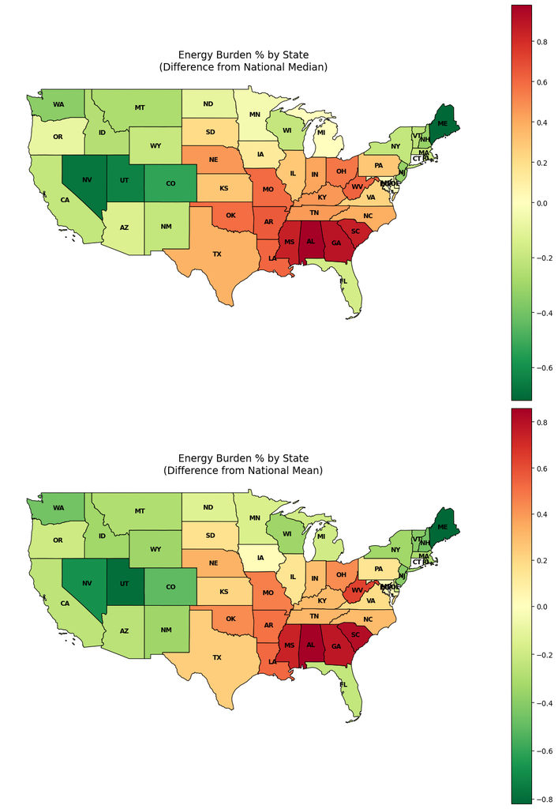

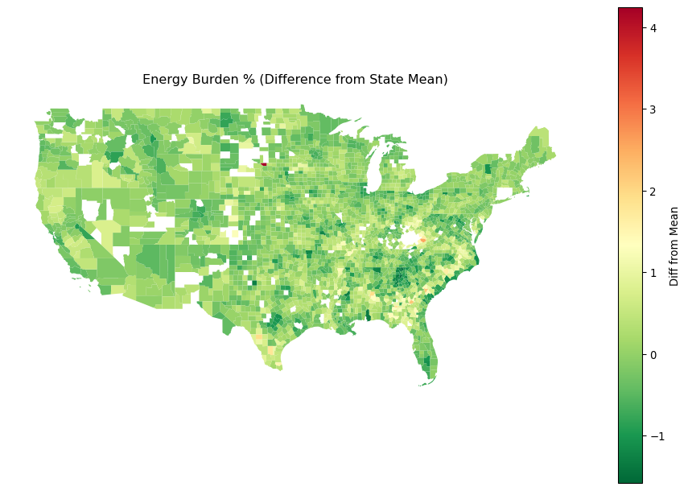

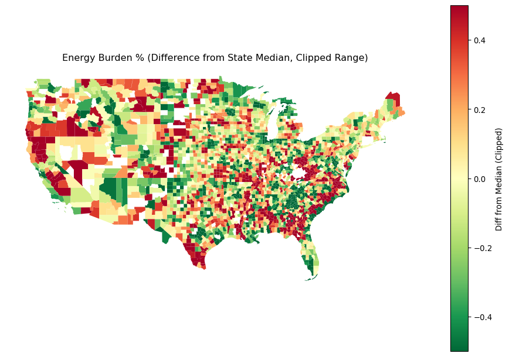

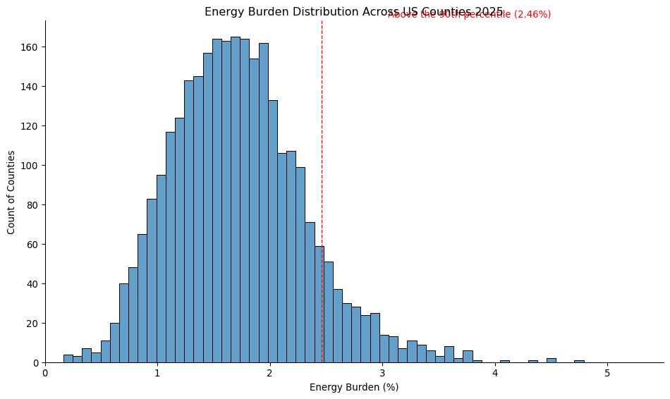

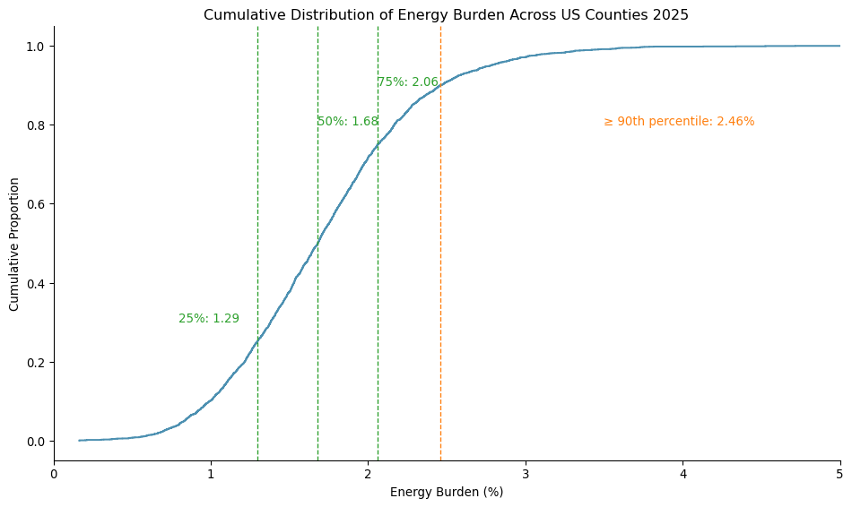

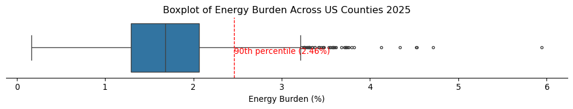

```
Summary Statistics for EBres in 2025:
count    2895.000000
mean        1.716950
std         0.599920
min         0.164146
25%         1.294954
50%         1.681417
75%         2.062347
max         5.946792
Name: EBres, dtype: float64
```

```python
res2025 = generate_EBres_summary(df2025btm, year_label="2025")
summary_EBres_2025 = res2025['summary']
plot_list_2025 = res2025['plots']
EB_heatmap(summary_EBres_2025)
EB_county_map(df2025btm, summary_EBres_2025)
plot_energy_burden_distribution(df2025btm, column="EBres", year_label="2025")
```

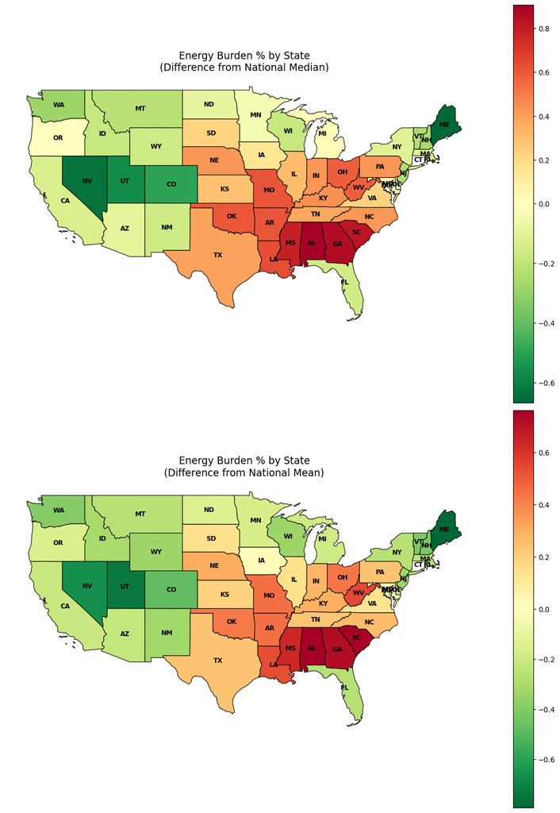

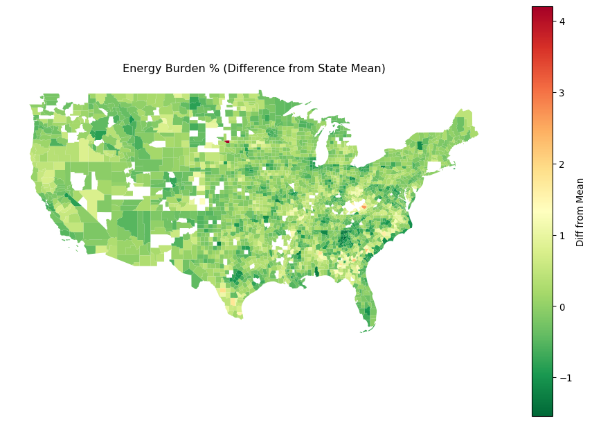

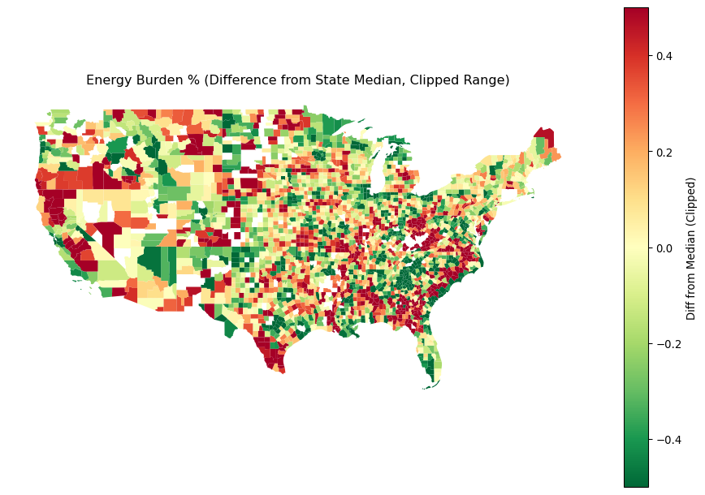

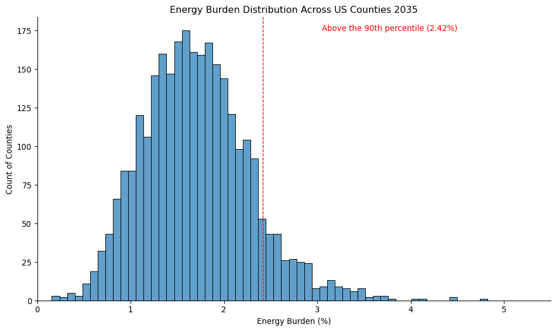

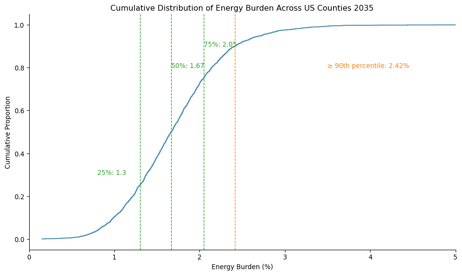

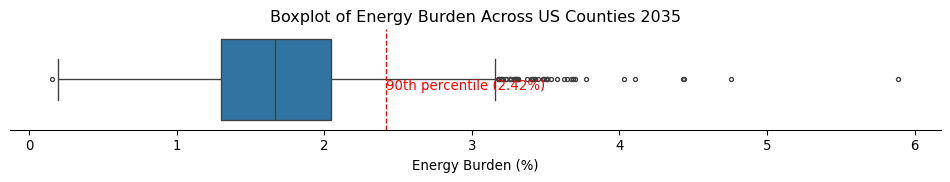

```
Summary Statistics for EBres in 2035:
count    2890.000000
mean        1.703651
std         0.579626
min         0.155100
25%         1.300852
50%         1.668422
75%         2.048134
max         5.890657
Name: EBres, dtype: float64
```

```python
res2035 = generate_EBres_summary(df2035btm, year_label="2035")
summary_EBres_2035 = res2035['summary']
plot_list_2035 = res2035['plots']
EB_heatmap(summary_EBres_2035)
EB_county_map(df2035btm, summary_EBres_2035)
plot_energy_burden_distribution(df2035btm, column="EBres", year_label="2035")
```

Data from Python is the same as R.

```python
import pandas as pd
import matplotlib.pyplot as plt
import seaborn as sns

def plot_energy_burden_summary(df, year):

    ebres = df["EBres"].dropna()
    percent_90 = round(np.percentile(ebres, 90), 2)


    df_above_90 = df[df["EBres"] >= percent_90]
    above_90_counts = df_above_90["state"].value_counts().reset_index()
    above_90_counts.columns = ["state", "above_90"]

    total_counts = df["state"].value_counts().reset_index()
    total_counts.columns = ["state", "total"]


    percentage_df = pd.merge(above_90_counts, total_counts, on="state", how="left")
    percentage_df["percentage"] = (percentage_df["above_90"] / percentage_df["total"]) * 100


    percentage_df_sorted = percentage_df.sort_values("percentage", ascending=True)


    plt.figure(figsize=(10, 6))
    sns.barplot(
        data=above_90_counts.sort_values("above_90"),
        x="above_90", y="state",
        color="darkseagreen", edgecolor="seagreen", alpha=0.8
    )
    plt.title(f"Counties Above 90th Percentile of Energy Burden by State ({year})", fontsize=14, weight="bold")
    plt.xlabel("Number of Counties")
    plt.ylabel("State")
    sns.despine()
    plt.tight_layout()
    plt.show()


    plt.figure(figsize=(10, 6))
    ax = sns.barplot(
        data=percentage_df_sorted,
        x="percentage", y="state",
        color="lightblue", edgecolor="steelblue", alpha=0.85
    )


    for bar in ax.patches:
        width = bar.get_width()
        y = bar.get_y() + bar.get_height() / 2
        ax.text(width + 0.5, y, f"{width:.1f}%", va='center', ha='left', fontsize=9)

    plt.title(f"Percentage of Counties ≥ 90th Percentile Energy Burden by State ({year})", fontsize=14, weight="bold")
    plt.xlabel("Percentage of Counties (%)")
    plt.ylabel("State")
    plt.xlim(0, percentage_df_sorted["percentage"].max() + 10)
    sns.despine()
    plt.tight_layout()
    plt.show()
    #print(percentage_df)
```

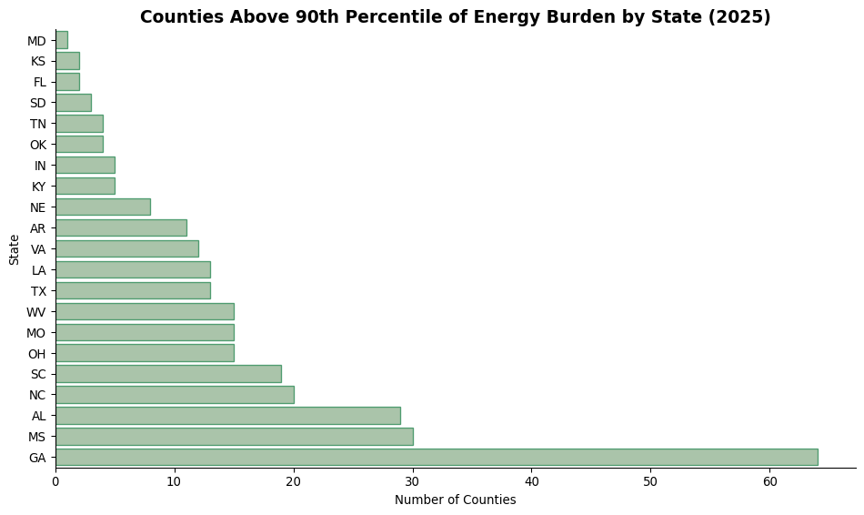

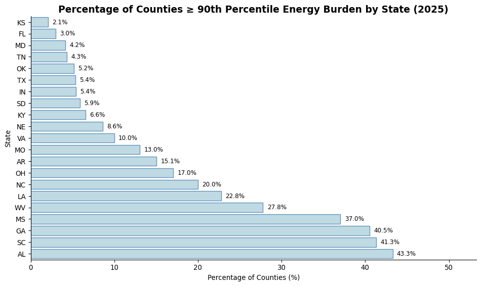

```python
plot_energy_burden_summary(df2025btm, year=2025)
```

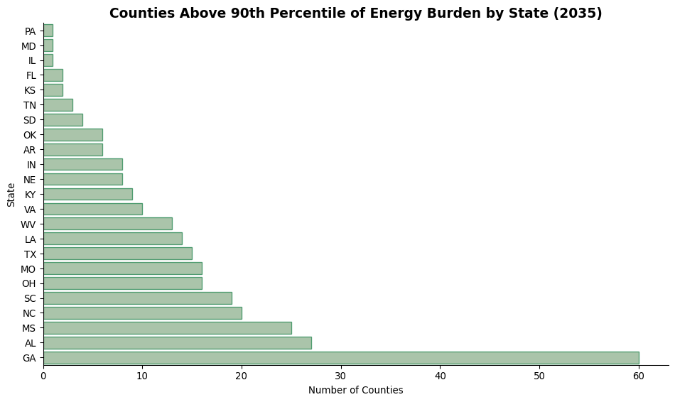

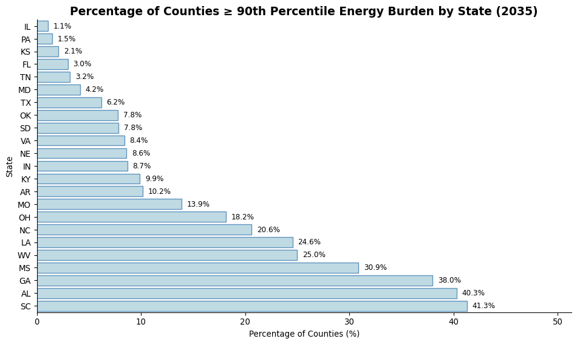

```python
plot_energy_burden_summary(df2035btm, year=2035)
```

## 3.2 $EB_{GDP}$ and $NER_{GDP}$ (at a county level)

```python
def generate_energy_gdp_summary(df, year_label="Year"):
    states = df['state'].dropna().unique()
    states = [state for state in states if state != "DC"]

    plot_list = []
    summary_energy_gdp = []

    for state in states:
        state_data = df[(df['state'] == state) & (df['energy_gdp'].notna())]

        if state_data.empty:
            continue

        mean_state = state_data['energy_gdp'].mean()
        median_state = state_data['energy_gdp'].median()
        sd_state = state_data['energy_gdp'].std()
        perc90 = state_data['energy_gdp'].quantile(0.9)

        summary_energy_gdp.append({
            'state': state,
            'mean_energy_gdp': mean_state,
            'median_energy_gdp': median_state,
            'sd_energy_gdp': sd_state
        })

        plt.figure(figsize=(8, 6))
        ax = sns.histplot(state_data['energy_gdp'], bins=15, color="darkseagreen", edgecolor="darkseagreen", alpha=0.7)
        plt.axvline(median_state, color="black", linestyle="--", linewidth=1)
        plt.axvline(perc90, color="red", linestyle="--", linewidth=1)

        plt.title(f"Energy GDP Distribution in {state} - {year_label}", fontsize=16)
        plt.xlabel("Energy GDP (%)", fontsize=14)
        plt.ylabel("Count of Counties", fontsize=14)
        plt.text(median_state - median_state / 5, 10, f"Median: {median_state:.2f}", color="black", fontsize=10)
        plt.text(median_state - median_state / 5, 9, f"90th Percentile: {perc90:.2f}", color="red", fontsize=10)

        plt.tight_layout()
        plot_list.append(plt.gcf())
        plt.close()

    summary_energy_gdp_df = pd.DataFrame(summary_energy_gdp)
    summary_energy_gdp_df = summary_energy_gdp_df.sort_values(by='mean_energy_gdp', ascending=False)

    national_mean = summary_energy_gdp_df['mean_energy_gdp'].mean()
    national_median = summary_energy_gdp_df['median_energy_gdp'].median()

    summary_energy_gdp_df['mean_comparison'] = summary_energy_gdp_df['mean_energy_gdp'].apply(lambda x: 'Above' if x > national_mean else 'Below')
    summary_energy_gdp_df['median_comparison'] = summary_energy_gdp_df['median_energy_gdp'].apply(lambda x: 'Above' if x > national_median else 'Below')

    return {
        'summary': summary_energy_gdp_df,
        'plots': plot_list
    }
```

```python
def energy_gdp_heatmap(df_summary):
    national_median = df_summary['median_energy_gdp'].median()
    national_mean = df_summary['mean_energy_gdp'].mean()
    df_summary = df_summary.copy()
    df_summary['difference_from_median'] = df_summary['median_energy_gdp'] - national_median
    df_summary['difference_from_mean'] = df_summary['mean_energy_gdp'] - national_mean

    response = requests.get('https://github.com/sabrilg-nrel/mapsusdatasupport/raw/main/cb_2020_us_state_20m.zip')
    with tempfile.TemporaryDirectory() as tmpdirname:
        zip_path = os.path.join(tmpdirname, "cb_2020_us_state_20m.zip")
        with open(zip_path, "wb") as f:
            f.write(response.content)

        with zipfile.ZipFile(zip_path) as z:
            z.extractall(tmpdirname)
            shapefile_name = [f for f in z.namelist() if f.endswith('.shp')][0]
            shapefile_path = os.path.join(tmpdirname, shapefile_name)
            states_gdf = gpd.read_file(shapefile_path)

    states_gdf = states_gdf[~states_gdf['STUSPS'].isin(['AK', 'HI', 'PR'])]

    merged_gdf = states_gdf.merge(df_summary, left_on='STUSPS', right_on='state', how='left')

    cmap = plt.cm.get_cmap('RdYlGn_r')

    fig, axes = plt.subplots(2, 1, figsize=(12, 16))

    # Difference from median
    vmin_median, vmax_median = merged_gdf['difference_from_median'].min(), merged_gdf['difference_from_median'].max()
    norm_median = mcolors.TwoSlopeNorm(vmin=vmin_median, vcenter=0, vmax=vmax_median)
    merged_gdf.plot(column='difference_from_median', cmap=cmap, norm=norm_median,
                    linewidth=0.8, edgecolor='black', ax=axes[0], legend=True)
    axes[0].set_title('Energy GDP % by State\n(Difference from National Median)', fontsize=14)
    axes[0].axis('off')

    # Difference from mean
    vmin_mean, vmax_mean = merged_gdf['difference_from_mean'].min(), merged_gdf['difference_from_mean'].max()
    norm_mean = mcolors.TwoSlopeNorm(vmin=vmin_mean, vcenter=0, vmax=vmax_mean)
    merged_gdf.plot(column='difference_from_mean', cmap=cmap, norm=norm_mean,
                    linewidth=0.8, edgecolor='black', ax=axes[1], legend=True)
    axes[1].set_title('Energy GDP % by State\n(Difference from National Mean)', fontsize=14)
    axes[1].axis('off')

    for ax in axes:
        for idx, row in merged_gdf.iterrows():
            x, y = row['geometry'].centroid.coords.xy
            ax.text(x[0], y[0], row['STUSPS'], fontsize=9, fontweight='bold',
                    ha='center', va='center', color='black')

    plt.tight_layout()
    plt.show()
```

```python
def energy_gdp_county_map(df, summary_df):
    threshold = 0.5

    summary_df = summary_df.dropna(subset=['state', 'mean_energy_gdp', 'median_energy_gdp'])
    df = df.merge(summary_df[['state', 'mean_energy_gdp', 'median_energy_gdp']], on='state', how='left')

    df['county_color_mean'] = df['energy_gdp'].lt(df['mean_energy_gdp']).map({True: 'Below', False: 'Above'})
    df['county_color_median'] = df['energy_gdp'].lt(df['median_energy_gdp']).map({True: 'Below', False: 'Above'})
    df['difference_from_mean'] = df['energy_gdp'] - df['mean_energy_gdp']
    df['difference_from_median'] = df['energy_gdp'] - df['median_energy_gdp']
    df['difference_from_median'] = df['difference_from_median'].clip(lower=-threshold, upper=threshold)

    url = 'https://github.com/sabrilg-nrel/mapsusdatasupport/raw/main/cb_2020_us_county_20m.zip'
    response = requests.get(url)
    with tempfile.TemporaryDirectory() as tmpdir:
        zip_path = os.path.join(tmpdir, "counties.zip")
        with open(zip_path, "wb") as f:
            f.write(response.content)
        with zipfile.ZipFile(zip_path) as z:
            z.extractall(tmpdir)
            shp_file = [f for f in z.namelist() if f.endswith('.shp')][0]
            shp_path = os.path.join(tmpdir, shp_file)
            counties = gpd.read_file(shp_path)

    counties = counties[~counties['STATEFP'].isin(['02', '15', '72'])]
    df['fips'] = df['fips'].astype(str).str.zfill(5)
    counties['fips'] = counties['STATEFP'] + counties['COUNTYFP']
    counties = counties.merge(df, on='fips', how='left')

    cont_cmap = plt.cm.get_cmap('RdYlGn_r')

    # Plot 3: Gradient from State Mean
    fig3, ax3 = plt.subplots(figsize=(12, 8))
    counties.plot(column='difference_from_mean', cmap=cont_cmap, legend=True,
                legend_kwds={'label': "Diff from Mean"},
                ax=ax3, edgecolor='none')
    ax3.set_title("Energy GDP % (Difference from State Mean)")
    ax3.axis('off')

    # Plot 4: Gradient from State Median (Clipped)
    fig4, ax4 = plt.subplots(figsize=(12, 8))
    counties.plot(column='difference_from_median', cmap=cont_cmap, legend=True,
                legend_kwds={'label': "Diff from Median (Clipped)"},
                ax=ax4, edgecolor='none')
    ax4.set_title("Energy GDP % (Difference from State Median, Clipped Range)")
    ax4.axis('off')

    plt.show()
```

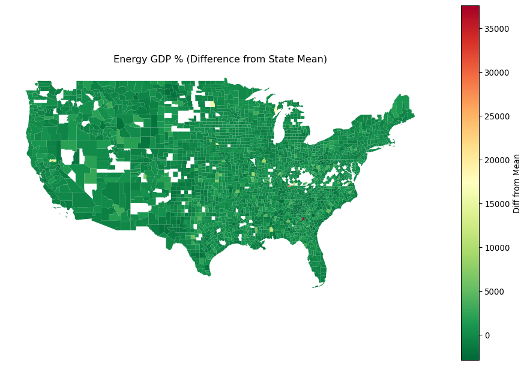

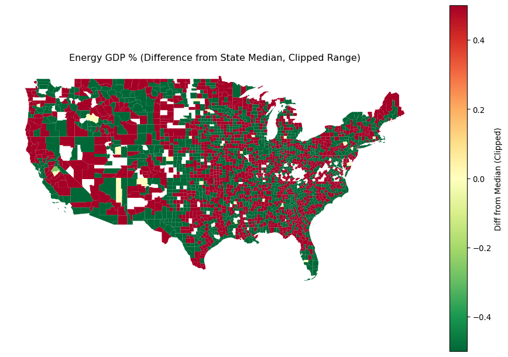

```python
result = generate_energy_gdp_summary(df2025btm)
summary_df = result['summary']
plots = result['plots']
energy_gdp_county_map(df2025btm, summary_df)
```

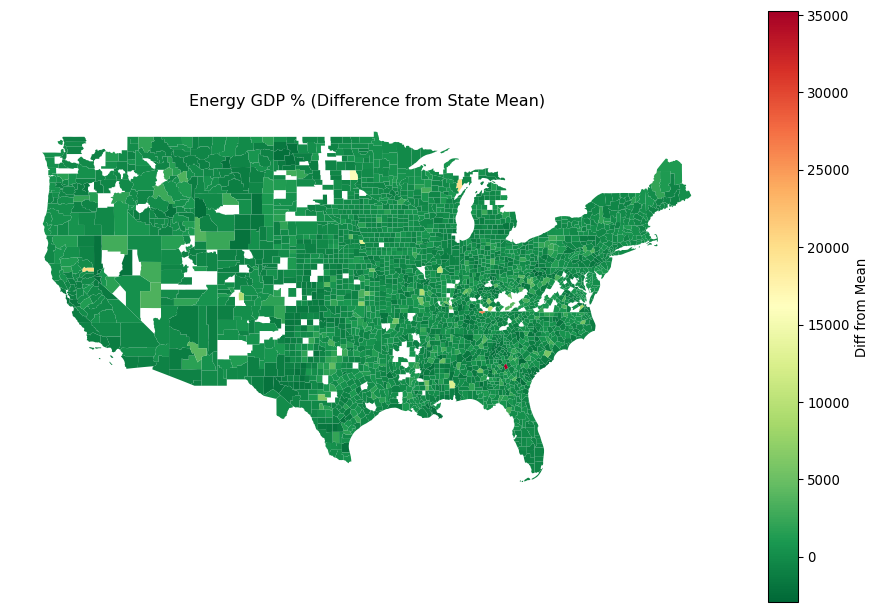

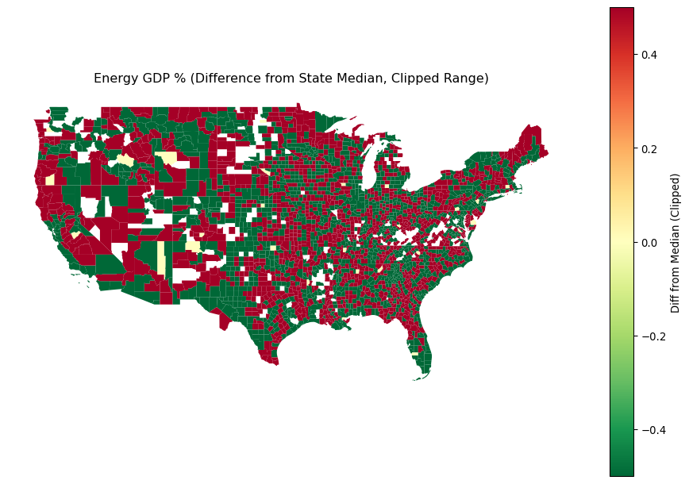

```python
result = generate_energy_gdp_summary(df2035btm)
summary_df = result['summary']
plots = result['plots']
energy_gdp_county_map(df2035btm, summary_df)
```

Values are coincident for R and Python.

## 3.3 AEP-to-demand ratio

Since the literature talk about more AEP. we need to check the distribution of AEP/demand and compare to AEP non standarized. First we check the distribution.

```python
import matplotlib.pyplot as plt
import seaborn as sns
from scipy.stats import ks_2samp, zscore

def plot_histograms(df, label):
    sns.set_theme(style="whitegrid")
    fig, axes = plt.subplots(1, 2, figsize=(14, 6))

    ks_stat, p_value = ks_2samp(df['aep_demand'], df['cost_viable_aep_sum_twh'])

    # AEP Demand standarized
    sns.histplot(
        df['aep_demand'],
        bins=int((df['aep_demand'].max() - df['aep_demand'].min()) / 0.00001),
        ax=axes[0],
        color="#1f77b4",
        edgecolor="black",
        alpha=0.7
    )
    axes[0].set_title(f"AEP/Demand (TWh/TWh) - {label}", fontsize=14, fontweight="bold")
    axes[0].set_xlabel("AEP Demand", fontsize=12)
    axes[0].set_ylabel("Frequency", fontsize=12)
    axes[0].tick_params(axis='x', labelrotation=45)
    axes[0].set_title(f"AEP/Demand (TWh/TWh) - {label}")
    axes[0].text(0.5, -0.2, f"Data Source: {label}", transform=axes[0].transAxes,
                 ha='center', fontsize=9, style='italic')
    # Non standarized AEP.
    sns.histplot(
        df['cost_viable_aep_sum_twh'],
        bins=int((df['cost_viable_aep_sum_twh'].max() - df['cost_viable_aep_sum_twh'].min()) / 0.01),
        ax=axes[1],
        color="#ff7f0e",
        edgecolor="black",
        alpha=0.7
    )
    axes[1].set_title(f"AEP in TWh - {label}", fontsize=14, fontweight="bold")
    axes[1].set_xlabel("Economic AEP (TWh)", fontsize=12)
    axes[1].set_ylabel("Frequency", fontsize=12)
    axes[1].tick_params(axis='x', labelrotation=45)
    axes[1].set_title(f"AEP in TWh - {label}\nThe total Cost Viable AEP in TWh")
    axes[1].text(0.5, -0.2, f"Data Source: {label}", transform=axes[1].transAxes,
                 ha='center', fontsize=9, style='italic')

    print(f"[{label}] Kolmogorov–Smirnov Test:")
    print(f"  Statistic: {ks_stat:.4f}")
    print(f"  p-value:   {p_value:.4f}")
    if p_value < 0.05:
        print("  → The distributions are significantly different (p < 0.05)")
    else:
        print("  → The distributions are NOT significantly different (p ≥ 0.05)")

    plt.tight_layout()
    plt.show()
```

```
[2025 BTM] Kolmogorov–Smirnov Test:
  Statistic: 0.9461
  p-value:   0.0000
  → The distributions are significantly different (p < 0.05)
```

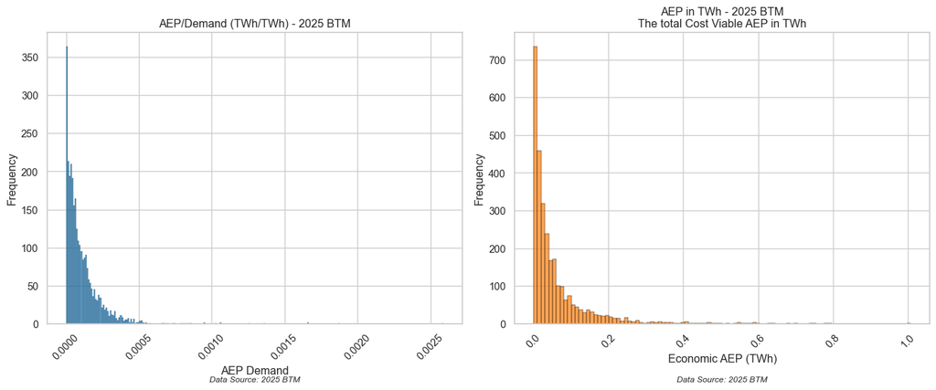

```
[2035 BTM] Kolmogorov–Smirnov Test:
  Statistic: 0.9312
  p-value:   0.0000
  → The distributions are significantly different (p < 0.05)
```

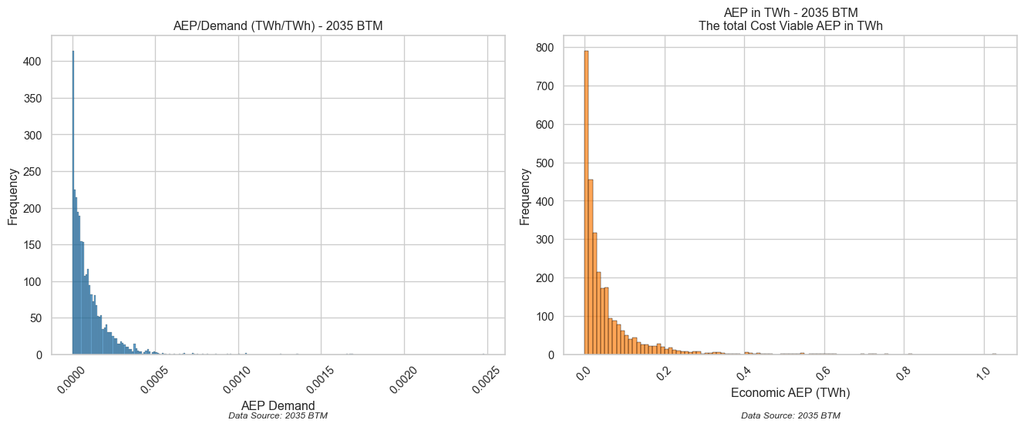

```python
plot_histograms(df2025btm, '2025 BTM')
plot_histograms(df2035btm, '2035 BTM')
```

```python
import numpy as np
import matplotlib.pyplot as plt
import seaborn as sns
from scipy.stats import boxcox_llf, boxcox, kstest

def plot_boxcox_lambda_and_transform(df, demand_col, econ_col, label):
    demand_data = df[demand_col][df[demand_col] > 0]
    econ_data = df[econ_col][df[econ_col] > 0]
    lambdas = np.linspace(-2, 2, 100)

    llf_demand = [boxcox_llf(lmb, demand_data) for lmb in lambdas] #Log-likelihood to lambdas
    llf_econ = [boxcox_llf(lmb, econ_data) for lmb in lambdas]

    # Optimal lambdas (rounded to 1 decimal for display)
    opt_lambda_demand = round(lambdas[np.argmax(llf_demand)], 1)
    opt_lambda_econ = round(lambdas[np.argmax(llf_econ)], 1)

    # Transform data using optimal lambdas
    transformed_demand, _ = transform_boxcox(demand_data, 0.3)
    transformed_econ, _ = transform_boxcox(econ_data, 0.2)

    sns.set_theme(style="whitegrid")
    fig, axes = plt.subplots(1, 2, figsize=(14, 6))

    # Plot AEP Demand log-likelihood
    axes[0].plot(lambdas, llf_demand, color="#1f77b4")
    axes[0].axvline(opt_lambda_demand, color='red', linestyle='--')
    axes[0].set_title(f"Box-Cox Trans for AEP Demand - {label}", fontsize=14, fontweight='bold')
    axes[0].set_xlabel("Lambda", fontsize=12)
    axes[0].set_ylabel("Log-Likelihood", fontsize=12)
    axes[0].text(0.5, 0.9, f"Optimal Lambda = {opt_lambda_demand:.1f}", transform=axes[0].transAxes,
                 ha='center', fontsize=11, style='italic')

    # Plot Economic AEP log-likelihood
    axes[1].plot(lambdas, llf_econ, color="#ff7f0e")
    axes[1].axvline(opt_lambda_econ, color='red', linestyle='--')
    axes[1].set_title(f"Box-Cox Trans for Economic AEP (TWh) - {label}", fontsize=14, fontweight='bold')
    axes[1].set_xlabel("Lambda", fontsize=12)
    axes[1].set_ylabel("Log-Likelihood", fontsize=12)
    axes[1].text(0.5, 0.9, f"Optimal Lambda = {opt_lambda_econ:.1f}", transform=axes[1].transAxes,
                 ha='center', fontsize=11, style='italic')

    plt.tight_layout()
    plt.show()

    # Return transformed columns and optimal lambdas for further use
    return transformed_demand, transformed_econ, opt_lambda_demand, opt_lambda_econ
```

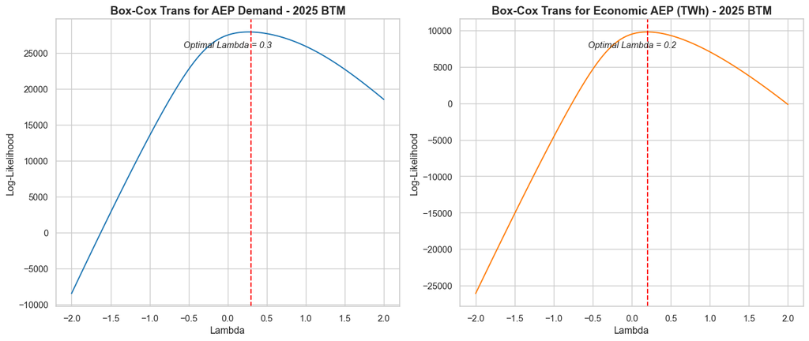

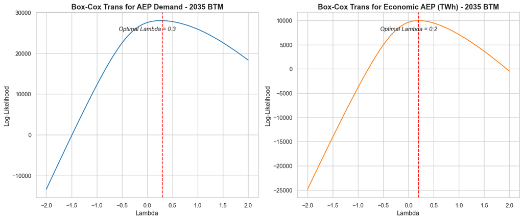

```python
trans_demand2025, trans_econ_2025, lmd_2025_s, lmd_2025_ns = plot_boxcox_lambda_and_transform(df2025btm, 'aep_demand', 'cost_viable_aep_sum_twh', '2025 BTM')
trans_demand2035, trans_econ_2035, lmd_2035_s, lmd_2035_ns = plot_boxcox_lambda_and_transform(df2035btm, 'aep_demand', 'cost_viable_aep_sum_twh', '2035 BTM')
```

```python
def plot_histograms_trans(transformed_demand, transformed_econ, label):
    sns.set_theme(style="whitegrid")
    fig, axes = plt.subplots(1, 2, figsize=(14, 6))

    # Histogram for transformed AEP Demand
    sns.histplot(transformed_demand, bins=30, color="#1f77b4", edgecolor="black", alpha=0.7, ax=axes[0])
    axes[0].set_title(f"Box-Cox Transformed AEP Demand - {label}", fontsize=14, fontweight="bold")
    axes[0].set_xlabel("Transformed AEP Demand", fontsize=12)
    axes[0].set_ylabel("Frequency", fontsize=12)
    axes[0].tick_params(axis='x', labelrotation=45)
    axes[0].text(0.5, -0.2, f"Data Source: {label}", transform=axes[0].transAxes,
                 ha='center', fontsize=9, style='italic')

    # Histogram for transformed Economic AEP
    sns.histplot(transformed_econ, bins=30, color="#ff7f0e", edgecolor="black", alpha=0.7, ax=axes[1])
    axes[1].set_title(f"Box-Cox Transformed Economic AEP (TWh) - {label}", fontsize=14, fontweight="bold")
    axes[1].set_xlabel("Transformed Economic AEP (TWh)", fontsize=12)
    axes[1].set_ylabel("Frequency", fontsize=12)
    axes[1].tick_params(axis='x', labelrotation=45)
    axes[1].text(0.5, -0.2, f"Data Source: {label}", transform=axes[1].transAxes,
                 ha='center', fontsize=9, style='italic')

    plt.tight_layout()
    plt.show()
```

```python
from scipy.stats import ks_2samp

def ks_test_on_transformed(transformed_demand, transformed_econ):
    ks_stat, p_value = ks_2samp(transformed_demand, transformed_econ)
    print(f"KS Statistic: {ks_stat:.4f}")
    print(f"P-value: {p_value:.4f}")

    if p_value < 0.05:
        print("Distributions are significantly different (reject H0).")
    else:
        print("No significant difference between distributions (fail to reject H0).")
```

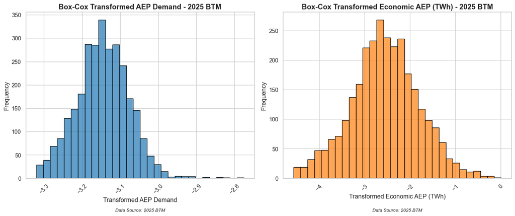

```
KS Statistic: 0.7296
P-value: 0.0000
Distributions are significantly different (reject H0).
```

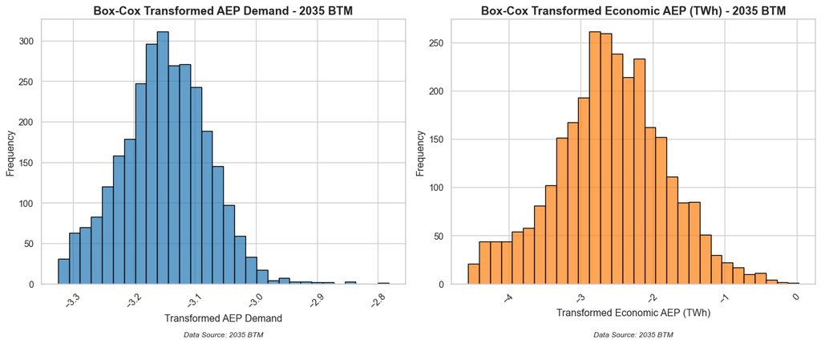

```
KS Statistic: 0.7113
P-value: 0.0000
Distributions are significantly different (reject H0).
```

```python
plot_histograms_trans(trans_demand2025, trans_econ_2025, '2025 BTM')
ks_test_on_transformed(trans_demand2025, trans_econ_2025)

plot_histograms_trans(trans_demand2035, trans_econ_2035, '2035 BTM')
ks_test_on_transformed(trans_demand2035, trans_econ_2035)
```

```python
import pandas as pd
import numpy as np
import matplotlib.pyplot as plt
import seaborn as sns

def plot_aep_demand_distribution(df, title=None):
    df = df.copy()

    # Compute median and classify
    aep_median = df['aep_demand'].median(skipna=True)
    df['aep_category'] = np.where(df['aep_demand'] > aep_median, 'Above Median', 'Below Median')

    # Count and percent per state
    count_df = (
        df.dropna(subset=['state', 'aep_category'])
          .groupby(['state', 'aep_category'])
          .size()
          .reset_index(name='n')
    )
    count_df['total'] = count_df.groupby('state')['n'].transform('sum')
    count_df['pct'] = count_df['n'] / count_df['total'] * 100
    count_df['pct_plot'] = np.where(
        count_df['aep_category'] == 'Below Median',
        -count_df['pct'],
        count_df['pct']
    )

    ### --- ALL STATES PLOT --- ###
    # Sort states by % Above Median
    sorted_states = (
        count_df[count_df['aep_category'] == 'Above Median']
        .sort_values(by='pct', ascending=False)['state']
        .dropna()
        .unique()
    )
    count_df['state'] = pd.Categorical(count_df['state'], categories=sorted_states, ordered=True)

    plt.figure(figsize=(10, max(6, len(sorted_states) * 0.3)))
    sns.barplot(
        data=count_df,
        y='state',
        x='pct_plot',
        hue='aep_category',
        dodge=False,
        palette={'Above Median': '#1f77b4', 'Below Median': 'red'},
        edgecolor='black',
        alpha=0.85
    )
    plt.xlabel("Percentage of Counties")
    plt.ylabel("State")
    plt.xticks(
        ticks=plt.xticks()[0],
        labels=[f"{abs(int(x))}%" for x in plt.xticks()[0]]
    )
    plt.legend(title="AEP Demand", loc='upper right')
    if title:
        plt.title(f"{title} (All States)")
    plt.grid(True, axis='x', linestyle='--', alpha=0.5)
    plt.tight_layout()
    plt.show()

    ### --- TOP 10 STATES ONLY --- ###
    # Get top 10 states based on "Above Median" pct
    top10_states = (
        count_df[count_df['aep_category'] == 'Above Median']
        .sort_values(by='pct', ascending=False)
        .head(10)['state']
        .dropna()
        .tolist()
    )

    count_top10 = count_df[count_df['state'].isin(top10_states)].copy()
    count_top10['state'] = pd.Categorical(
        count_top10['state'],
        categories=top10_states,
        ordered=True
    )

    plt.figure(figsize=(10, max(6, len(top10_states) * 0.6)))
    sns.barplot(
        data=count_top10,
        y='state',
        x='pct_plot',
        hue='aep_category',
        dodge=False,
        palette={'Above Median': '#1f77b4', 'Below Median': 'red'},
        edgecolor='black',
        alpha=0.85
    )
    plt.xlabel("Percentage of Counties")
    plt.ylabel("State")
    plt.xticks(
        ticks=plt.xticks()[0],
        labels=[f"{abs(int(x))}%" for x in plt.xticks()[0]]
    )
    plt.legend(title="AEP Demand", loc='upper right')
    if title:
        plt.title(f"{title} (Top 10 States Only)")
    plt.grid(True, axis='x', linestyle='--', alpha=0.5)
    plt.tight_layout()
    plt.show()
```

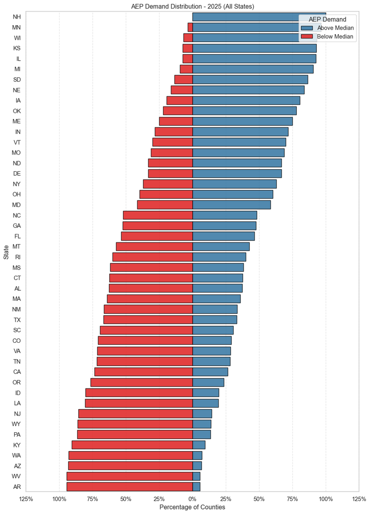

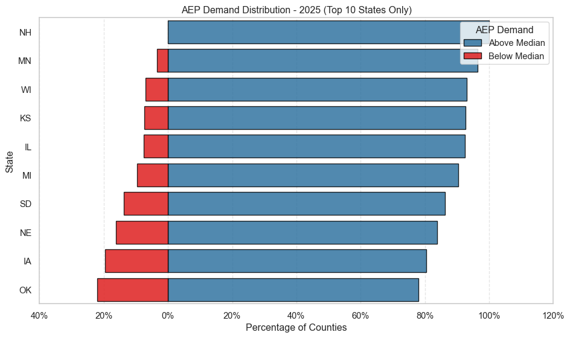

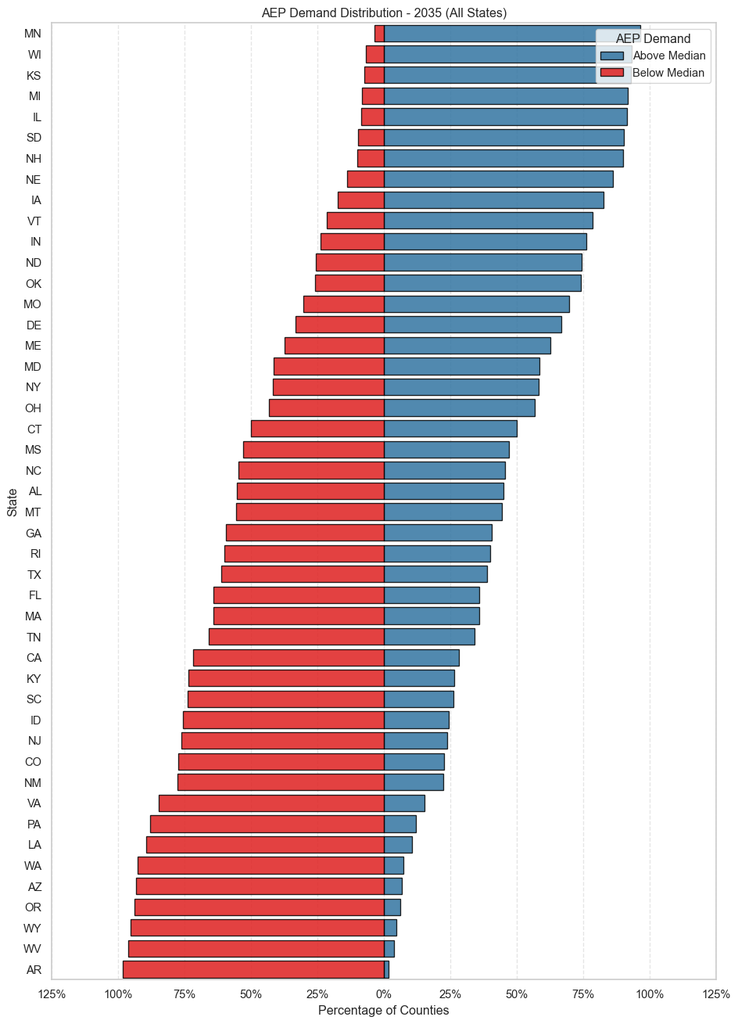

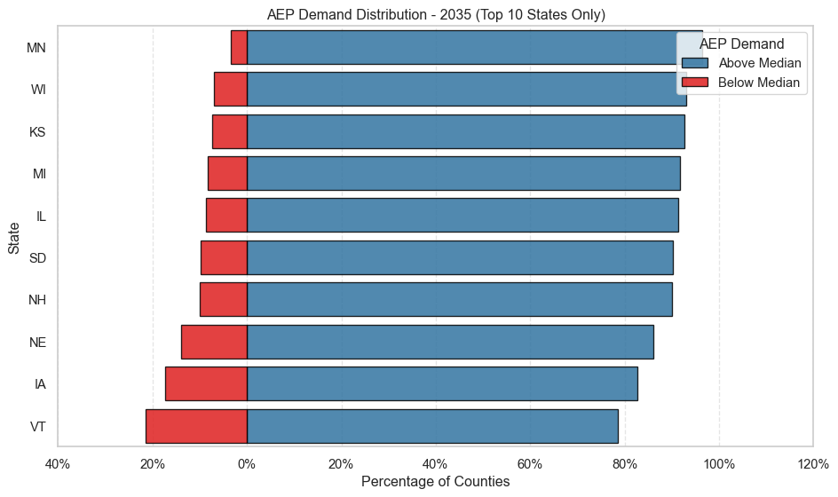

```python
plot_aep_demand_distribution(df2025btm, title="AEP Demand Distribution - 2025")
plot_aep_demand_distribution(df2035btm, title="AEP Demand Distribution - 2035")
```

AEP Residential demand

```python
import matplotlib.pyplot as plt
import seaborn as sns
from scipy.stats import ks_2samp

def plot_aepRES_histogram(df, label):
    sns.set_theme(style="whitegrid")
    fig, ax = plt.subplots(figsize=(8, 6))

    sns.histplot(
        df['aepRES_demand'],
        bins=int((df['aepRES_demand'].max() - df['aepRES_demand'].min()) / 0.00001),
        color="#1f77b4",
        edgecolor="black",
        alpha=0.7,
        ax=ax
    )
    ax.set_title(f"AEPRES/Demand (TWh/TWh) - {label}", fontsize=14, fontweight="bold")
    ax.set_xlabel("AEPRES Demand", fontsize=12)
    ax.set_ylabel("Frequency", fontsize=12)
    ax.tick_params(axis='x', labelrotation=45)
    ax.text(0.5, -0.2, f"Data Source: {label}", transform=ax.transAxes,
            ha='center', fontsize=9, style='italic')

    plt.tight_layout()
    plt.show()
def plot_aepRES_boxcox_histogram(transformed_aep, label):
    sns.set_theme(style="whitegrid")
    plt.figure(figsize=(8, 6))
    sns.histplot(transformed_aep, bins=30, color="#1f77b4", edgecolor="black", alpha=0.7)
    plt.title(f"Box-Cox Transformed AEPRES Demand - {label}", fontsize=14, fontweight="bold")
    plt.xlabel("Transformed AEPRES Demand", fontsize=12)
    plt.ylabel("Frequency", fontsize=12)
    plt.xticks(rotation=45)
    plt.grid(True, linestyle='--', alpha=0.5)
    plt.tight_layout()
    plt.show()
def ks_test_transformed_aepRES(transformed_aep, label):
    # Compare transformed AEPRES against a normal distribution
    from scipy.stats import norm

    ks_stat, p_value = ks_2samp(transformed_aep, norm.rvs(size=len(transformed_aep), random_state=42))
    print(f"[{label}] KS Test vs. Normal Distribution")
    print(f"  KS Statistic: {ks_stat:.4f}")
    print(f"  p-value:      {p_value:.4f}")
    if p_value < 0.05:
        print("  → Significantly different from normal (p < 0.05)")
    else:
        print("  → Not significantly different from normal (p ≥ 0.05)")
def plot_aepRES_demand_distribution(df, title=None):
    df = df.copy()

    # Compute median and classify
    aep_median = df['aepRES_demand'].median(skipna=True)
    df['aep_category'] = np.where(df['aepRES_demand'] > aep_median, 'Above Median', 'Below Median')

    # Count and percent per state
    count_df = (
        df.dropna(subset=['state', 'aep_category'])
          .groupby(['state', 'aep_category'])
          .size()
          .reset_index(name='n')
    )
    count_df['total'] = count_df.groupby('state')['n'].transform('sum')
    count_df['pct'] = count_df['n'] / count_df['total'] * 100
    count_df['pct_plot'] = np.where(
        count_df['aep_category'] == 'Below Median',
        -count_df['pct'],
        count_df['pct']
    )

    # Sort states by % Above Median
    sorted_states = (
        count_df[count_df['aep_category'] == 'Above Median']
        .sort_values(by='pct', ascending=False)['state']
        .dropna()
        .unique()
    )
    count_df['state'] = pd.Categorical(count_df['state'], categories=sorted_states, ordered=True)

    plt.figure(figsize=(10, max(6, len(sorted_states) * 0.3)))
    sns.barplot(
        data=count_df,
        y='state',
        x='pct_plot',
        hue='aep_category',
        dodge=False,
        palette={'Above Median': '#1f77b4', 'Below Median': 'red'},
        edgecolor='black',
        alpha=0.85
    )
    plt.xlabel("Percentage of Counties")
    plt.ylabel("State")
    plt.xticks(
        ticks=plt.xticks()[0],
        labels=[f"{abs(int(x))}%" for x in plt.xticks()[0]]
    )
    plt.legend(title="AEPRES Demand", loc='upper right')
    if title:
        plt.title(f"{title} (All States)")
    plt.grid(True, axis='x', linestyle='--', alpha=0.5)
    plt.tight_layout()
    plt.show()
```